# Pulmonic stenosis survival stats

## Summaries of coefficients

### a. HPDI for the different beta parameters

```r
draws <- as.matrix(mod_age)
median(draws[,2]) # draws for s_age)
```

```
## [1] 0.1589341
```

```r
HPDI(draws[,2], 0.97) # draws for s_age
```

```
##      |0.97      0.97|
## -0.1038816  0.4026029
```

```r
HPDI(draws[,2], 0.89) # raws for s_age
```

```
##       |0.89       0.89|
## -0.02054633  0.34039194
```

### b. Hypothesis tests on beta parameters

#### s_age

probability that effect is positive

```r
mean(draws[,2] > 0) # draws for s_age
```

```
## [1] 0.9147188
```

### c. Plot posterior distribution for beta coefficient of s_age

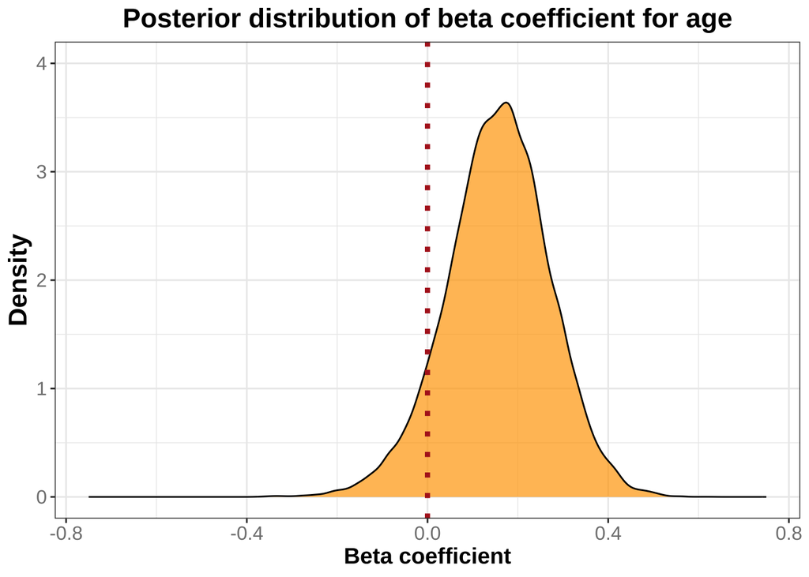

```r
s_age <- draws[,2] # 2nd column is draws for s_age

ggplot(data.frame(s_age), aes(x = s_age)) +
  geom_density(fill = "orange", alpha = 0.7) +
  labs(title = "Posterior distribution of beta coefficient for age",
       x = "Beta coefficient",
       y = "Density") +
  theme_bw() +
           theme(axis.title.y = element_text(size=16, face="bold"),
               axis.title.x = element_text(size=14, face="bold"),
               title = element_text(size=14, face="bold"),
               plot.title = element_text(hjust = 0.5),
               axis.text.x = element_text(color = "grey50", size = 12),
               axis.text.y = element_text(color = "grey50",size = 12)) +
  geom_vline(xintercept = 0, linetype="dotted",
                color = "firebrick", linewidth = 1.5) +
  xlim(-0.75, 0.75) +
  ylim(0, 4)
```

## Get HDI for coefficients

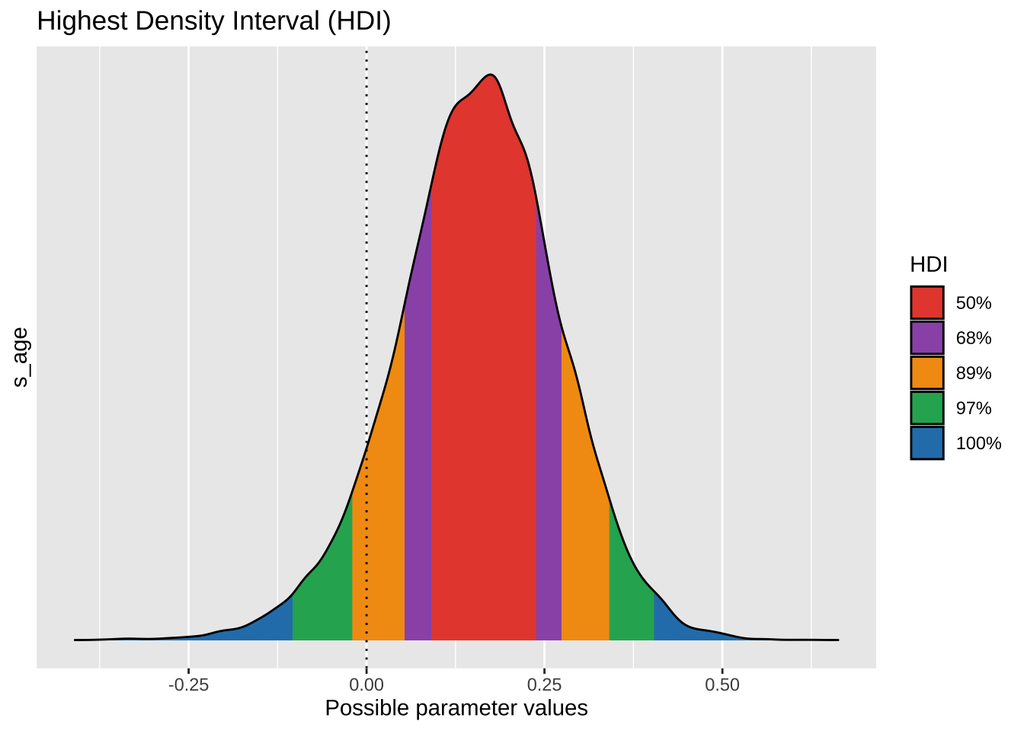

```r
hdi <- bayestestR::hdi(mod_age, ci = c(0.50, 0.68, 0.89, 0.97), parameters = "s_age")
plot(hdi)
```

## Get density plots for posterior distributons of beta parameters

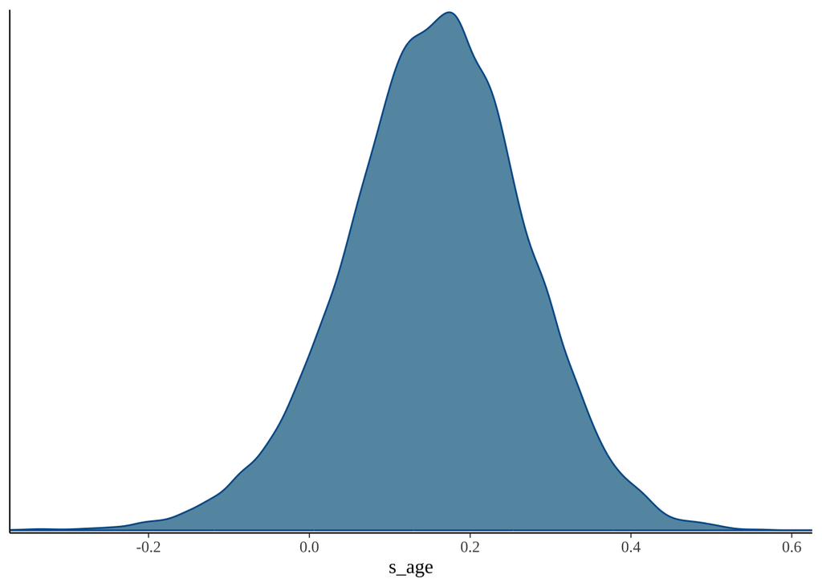

```r
mcmc_dens(posterior_mod_age,
  pars = c("s_age"))
```

## Get area plot for posterior distributons of beta parameters

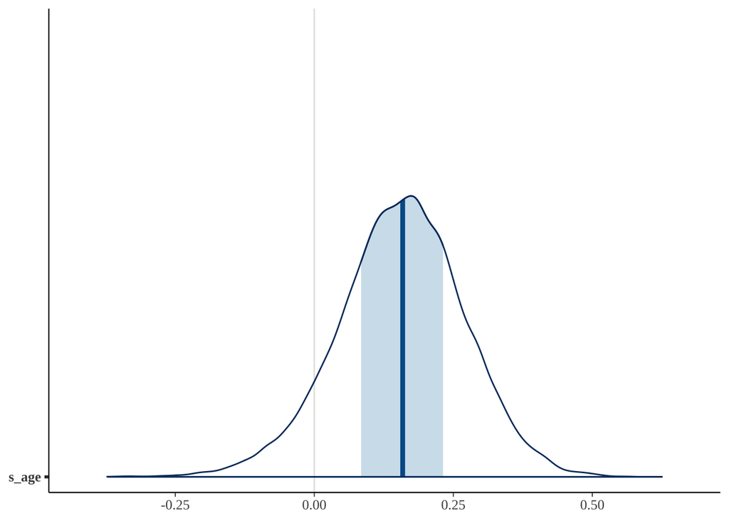

```r
mcmc_areas(posterior_mod_age,
  pars = "s_age")
```

## Calculate hazard ratios for s_age

### a. get posterior draws

```r
s_age_hr <- exp(draws[,2]) # 2nd column is draws for s_age)
```

### b. Summarise hazard ratios for s_age

```r
median(s_age_hr)
```

```
## [1] 1.172261
```

```r
hpdi_s_age_hr <- HPDI(s_age_hr, prob = c(0.89, 0.97))
hpdi_s_age_hr
```

```
##     |0.97     |0.89     0.89|     0.97|
## 0.8840504 0.9665168 1.3903191 1.4760499
```

### c. Plot posterior distribution for hazard ratio of s_age

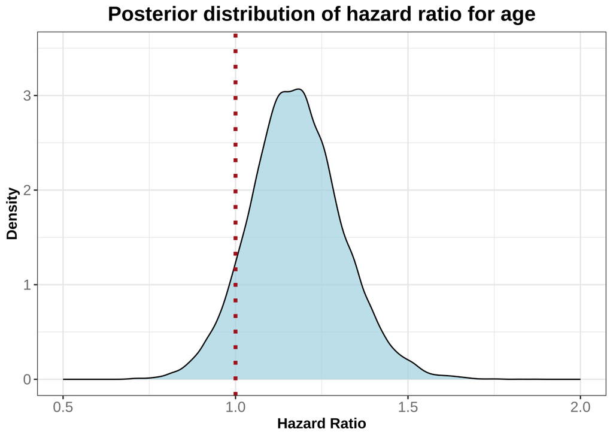

```r
ggplot(data.frame(s_age_hr), aes(x = s_age_hr)) +
  geom_density(fill = "lightblue", alpha = 0.7) +
  labs(title = "Posterior distribution of hazard ratio for age",
       x = "Hazard Ratio",
       y = "Density") +
  theme_bw() +
           theme(axis.title.y = element_text(size=12, face="bold"),
               axis.title.x = element_text(size=12, face="bold"),
               title = element_text(size=14, face="bold"),
               plot.title = element_text(hjust = 0.5),
               axis.text.x = element_text(color = "grey50", size = 12),
               axis.text.y = element_text(color = "grey50",size = 12)) +
  geom_vline(xintercept = 1, linetype="dotted",
                color = "firebrick", linewidth = 1.5) +
  xlim(0.5, 2.0) +
  ylim(0, 3.5)
```

## Check model performance

### 1.Check performance of posterior probability

NB equivalent of pp_check

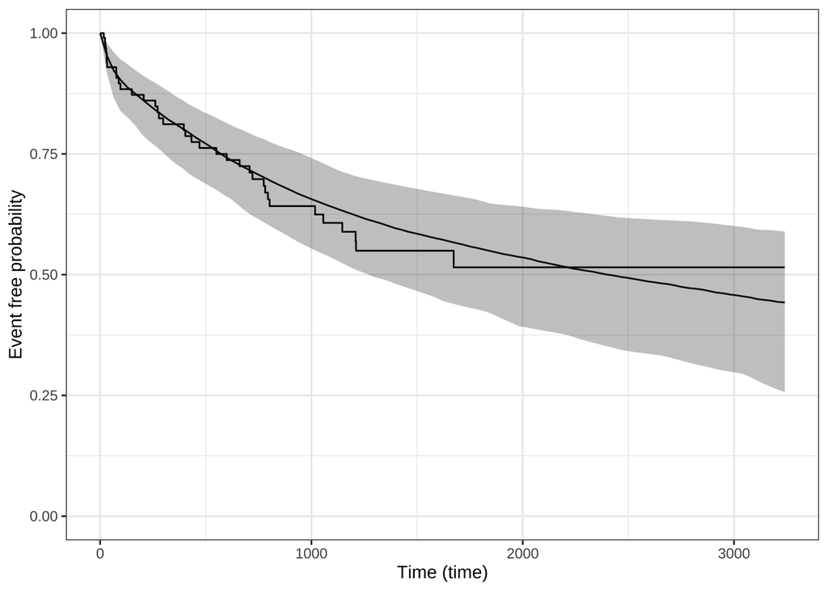

```r
ps_check(mod_age) |>
  suppressWarnings()
```

### 2. Check performance of prior probability

```r
mod_age_prior_only <- update(mod_age, prior_PD = TRUE)
```

[output not shown]

[output not shown]

[output not shown]

[output not shown]

[output not shown]

[output not shown]

[output not shown]

[output not shown]

[output not shown]

[output not shown]

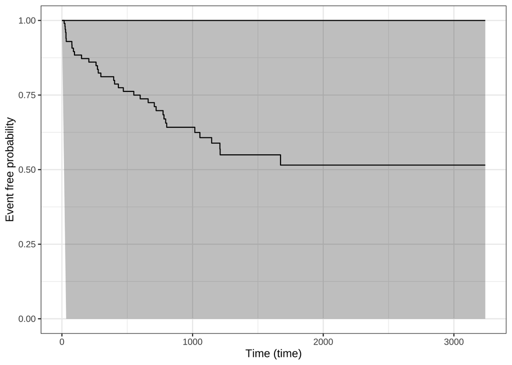

```r
ps_check(mod_age_prior_only)  |>
  suppressWarnings()
```

### 3. Check prosterior vs prior for beta variable

#### a. extract draws for posterior and prior

```r
# extract draws
post_draws  <- as.matrix(mod_age)
prior_draws <- as.matrix(mod_age_prior_only)
```

#### b. plot marginal distributions for posterior and prior

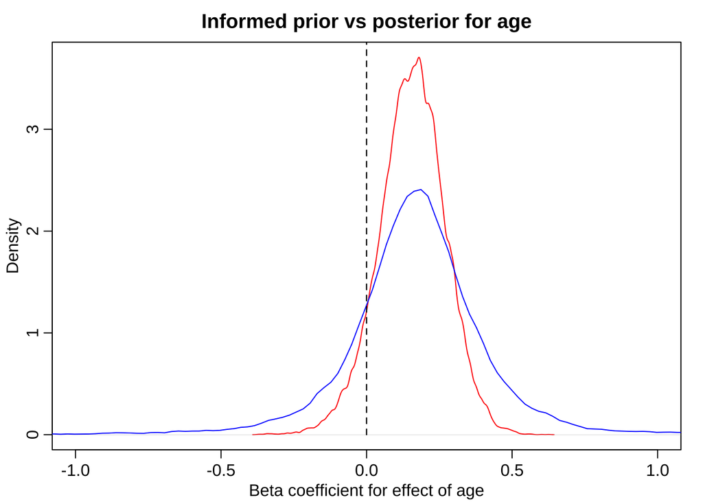

```r
# Compare marginal distributions
dens(post_draws[, "s_age"], show.zero = TRUE, col = "red", main = "Informed prior vs posterior for age",
     xlab = "Beta coefficient for effect of age", xlim = c(-1, 1))
dens(prior_draws[, "s_age"], add=TRUE, col = "blue", show.zero = TRUE)
```

#### c. compute prior tail probability of posterior mean

If this probability is very small (e.g. < 0.05), the posterior lies in a region the prior considered implausible.

```r
beta_hat <- mean(post_draws[, "s_age"])

mean(abs(prior_draws[, "s_age"] - beta_hat) <
       abs(prior_draws[, "s_age"] - mean(prior_draws[, "s_age"])))
```

```
## [1] 0.4801875
```

### 4. Sensitivity analyses to assess robustness of results to choice of prior

#### a. create priors of different strength for s_age variable

To determine whether the substantive conclusions depend upon the exact prior choice.

NB the scale variable is strengthened or weakened by multiplying or dividing the scale of the main prior by 2, respectively. The location is set to the posterior mean from the main model, to ensure that the priors are centred on a plausible value.

```r
priors_bin <- list(
  weak = student_t(df = 3, location = 0.1731489, scale = 0.6384379, autoscale = FALSE),
  moderate = student_t(df = 3, location = 0.1731489, scale = 0.3192190, autoscale = FALSE),
  strong = student_t(df = 3, location = 0.1731489, scale = 0.1596095, autoscale = FALSE)
)
```

**Set an informative, regularising prior…**

student_t(df = 3, location = 0.3086223, scale = 0.1497119) NB set at 0.5 given that ther scale is so small, to ensure that the data are not overwhelmed by the prior, but still allow for some regularisation to improve model convergence and reduce overfitting.

strong 0.1596095 moderate 0.3192190 weak 0.6384379

#### b. refit model with different priors and compare results

```r
fits <- lapply(priors_bin, function(p) {
  stan_surv(formula = Surv(time, status) ~ s_age
            + (1| centre),
            basehaz = "ms",
            data = df,
            prior_intercept = normal(location = 0, scale = 20, autoscale = FALSE),
            prior = p,
            prior_covariance =  decov(regularization = 2, concentration = 1, shape = 1, scale = 1),
            iter    = 2000,
            chains = 4,
            cores = 4,
            adapt_delta = 0.9999,  # Often helpful for complex models
            seed = 666
            )
})
```

[output not shown]

[output not shown]

[output not shown]

[output not shown]

[output not shown]

[output not shown]

[output not shown]

[output not shown]

[output not shown]

[output not shown]

[output not shown]

[output not shown]

[output not shown]

[output not shown]

[output not shown]

[output not shown]

[output not shown]

[output not shown]

[output not shown]

[output not shown]

[output not shown]

[output not shown]

[output not shown]

[output not shown]

[output not shown]

[output not shown]

[output not shown]

[output not shown]

[output not shown]

```r
# calculate median hazard ratio across different priors
HR_med_sens <- sapply(fits, function(f) {
  posterior::as_draws_df(f) |>
    as.data.frame() |>
    summarise(
      median = exp(quantile(s_age, probs = 0.5))
    )
})
HR_med <- c(HR_med_sens[[1]], HR_med_sens[[2]], HR_med_sens[[3]])


# calculate 89% credible interval for hazard ratio across different priors
HR_sens <- sapply(fits, function(f) {
  exp(posterior_interval(f, pars = "s_age", prob = 0.89))
})

# combine median and credible intervals into a summary table
HR_sens_summary <- rbind(HR_med, HR_sens)
row.names(HR_sens_summary) <- c("Median", "Lower", "Upper")

# transpose the table for better readability
HR_sens_summary
```

```
##             weak  moderate    strong
## Median 1.1584718 1.1592879 1.1708277
## Lower  0.8904465 0.9134312 0.9688442
## Upper  1.4646085 1.4377496 1.4013589
```

## Make model predictions and plot for age

### 1. Create new data where age differs

```r
nd <- data.frame(centre = rep("p", 5),
                 s_age = c(-0.86, -0.6, 0, 0.33, 5.8))
head(nd)
```

```
##   centre s_age
## 1      p -0.86
## 2      p -0.60
## 3      p  0.00
## 4      p  0.33
## 5      p  5.80
```

### 2. Make posterior predictions from new data

```r
ps <- posterior_survfit(mod_age,
  newdata = nd,
  times = 0,
  extrapolate = TRUE) |>
  suppressWarnings()
head(ps)
```

```
## stan_surv predictions
##  num. individuals: 5
##  prediction type:  event free probability
##  standardised?:    no
##  conditional?:     no
##
##   id cond_time     time median  ci_lb  ci_ub
## 1  1        NA   0.0000 1.0000 1.0000 1.0000
## 2  1        NA  32.7273 0.9681 0.9228 0.9908
## 3  1        NA  65.4545 0.9473 0.8784 0.9820
## 4  1        NA  98.1818 0.9327 0.8523 0.9749
## 5  1        NA 130.9091 0.9217 0.8330 0.9710
## 6  1        NA 163.6364 0.9145 0.8162 0.9670
```

### 3. Plot

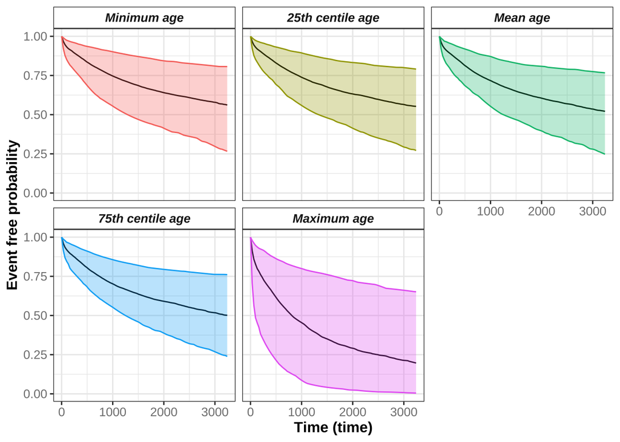

```r
panel_labels <- c('1' = "Minimum age", '2' = "25th centile age",
                  '3' = "Mean age", '4' = "75th centile age",
                  '5' = "Maximum age")
pps <- plot(ps) +
  aes(colour = factor(id), fill = factor(id)) +
  theme(legend.position = "none") +
  facet_wrap(~ id, labeller = labeller(id = panel_labels)) +
           theme(axis.title.y = element_text(size=12, face="bold"),
               axis.title.x = element_text(size=12, face="bold"),
               title = element_text(size=12, face="bold"),
               plot.title = element_text(hjust = 0.5),
               axis.text.x = element_text(color = "grey50", size = 10),
               axis.text.y = element_text(color = "grey50",size = 10)) +
            theme(strip.text.x = element_text(size = 10, face = "bold.italic"),
                   strip.background = element_rect(fill="white")
        )

print(pps)
```

## Check PH assumption visually

### make predictions of both the hazard and log hazard

```r
ph <- suppressWarnings( posterior_survfit(mod_age, newdata = nd, type = "haz") )
pl <- suppressWarnings( posterior_survfit(mod_age, newdata = nd, type = "loghaz") )
```

#### create plots

```r
pph <- plot(ph) +
  facet_wrap(~ id, labeller = labeller(id = panel_labels))
ppl <- plot(pl) +
  facet_wrap(~ id, labeller = labeller(id = panel_labels))
```

#### combine plots in grid and plot

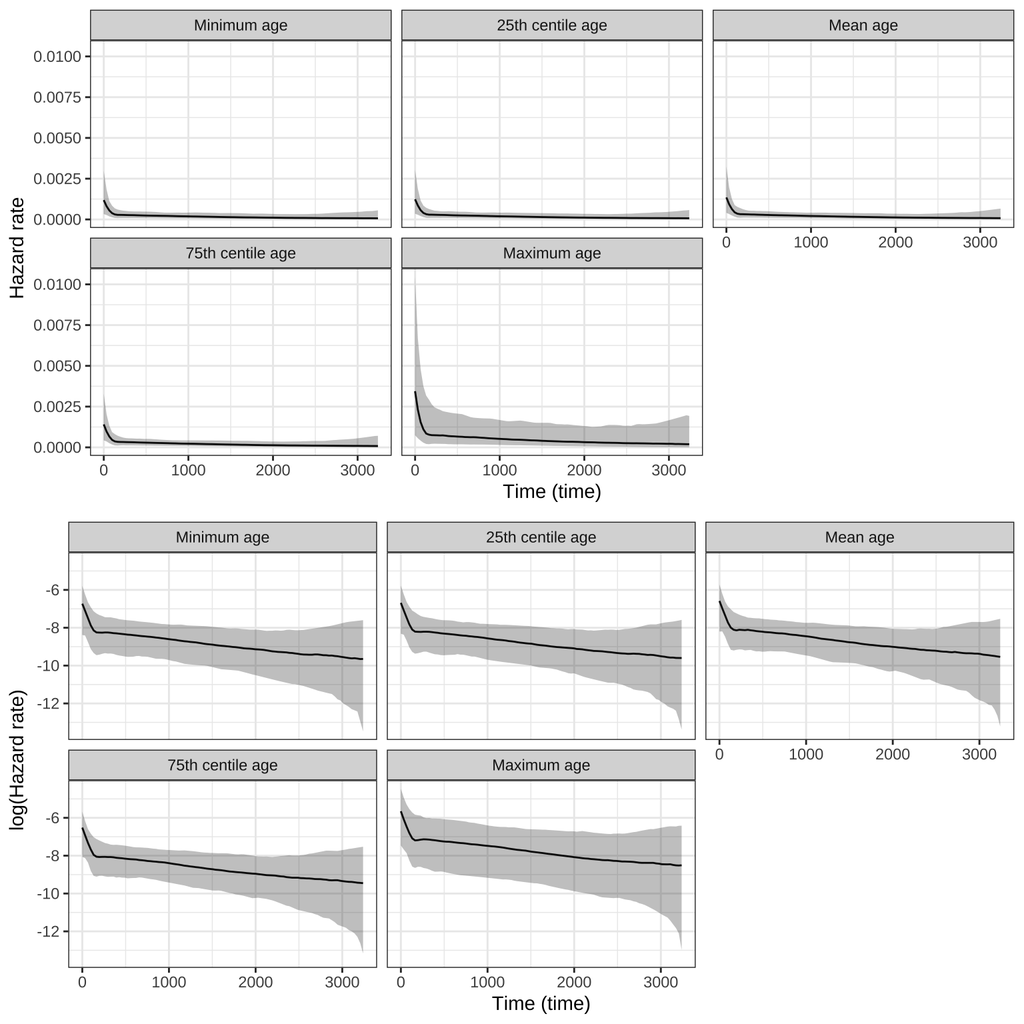

```r
plot_grid(pph, ppl, ncol = 1)
```

# III. Bayesian multi-level survival analysis for EFFECT OF SURGERY (surgery y/n) with random intercept for centre

## Set prior for beta variables

**Set an informative prior…**

student_t(df = 3, location = -0.879165, scale = 0.2911939)

```r
prior_beta_sx <- student_t(df = 3, location = c(-0.879165, 0, 0, 0, 0, 0, 0),
                           scale = c(0.29119395, 1.5, 1.5, 1.5, 1.5, 1.5, 1.5),
                           autoscale = c(FALSE, TRUE, FALSE, FALSE, FALSE, FALSE, TRUE))
```

NB needed to set a tighter scale variable for prior_intercept and also prior_beta_sx in order to improve regularisation and resolve divergent transitions.

Based on the DAG, use the following adjustment variables: age, clin signs, concurrent congen, pressure grad, referral centre, stenosis type.

## Fit model with for surgery (plus correction set)

NB use status … rstanarm requires the dead animals to be classified as 1, whilst censored are 0.

```r
mod_sx <- stan_surv(formula = Surv(time, status) ~ surgery
                    + s_age
                    + concurrent_congenital
                    + type
                    + clinical_signs
                    + s_pv_max_pg
                    + (1| centre),
  data = df,
  basehaz = "ms",
  prior_intercept = normal(location = 0, scale = 20, autoscale = FALSE),
  prior = prior_beta_sx,
  prior_covariance =  decov(regularization = 2, concentration = 1, shape = 1, scale = 1),
  iter    = 12000,
  warmup = 4000,
  chains = 4,
  cores = 4,
  adapt_delta = 0.9999999,  # Often helpful for complex models
  seed = 666)
```

[output not shown]

[output not shown]

[output not shown]

[output not shown]

[output not shown]

[output not shown]

[output not shown]

[output not shown]

[output not shown]

## Summarise priors from model

```r
prior_summary(mod_sx)
```

```
## Priors for model 'mod_sx'
## ------
## Intercept
##  ~ normal(location = 0, scale = 20)
##
## Coefficients
##  ~ student_t(df = [3,3,3,...], location = [-0.88, 0.00, 0.00,...], scale = [0.29,1.50,1.50,...])
##
## Auxiliary (M-spline-coefficients)
##  ~ dirichlet(concentration = [1,1,1,...])
##
## Covariance
##  ~ decov(reg. = 2, conc. = 1, shape = 1, scale = 1)
## ------
## See help('prior_summary.stanreg') for more details
```

## Model summary

```r
summary(mod_sx)
```

```
##
## Model Info:
##
##  function:        stan_surv
##  baseline hazard: M-splines on hazard scale
##  formula:         Surv(time, status) ~ surgery + s_age + concurrent_congenital +
##     type + clinical_signs + s_pv_max_pg + (1 | centre)
##  algorithm:       sampling
##  sample:          32000 (posterior sample size)
##  priors:          see help('prior_summary')
##  observations:    110
##  events:          36 (32.7%)
##  right censored:  74 (67.3%)
##  delayed entry:   no
##
## Estimates:
##                                         mean   sd   10%   50%   90%
## (Intercept)                           -0.4    0.6 -1.2  -0.4   0.3
## surgery1                              -0.8    0.3 -1.2  -0.8  -0.5
## s_age                                 -0.1    0.2 -0.3  -0.1   0.2
## concurrent_congenital1                 0.8    0.4  0.4   0.8   1.3
## typeb                                 -0.3    0.6 -1.0  -0.3   0.4
## typeintermediate                       0.2    0.4 -0.3   0.2   0.7
## clinical_signs                         1.5    0.4  0.9   1.5   2.0
## s_pv_max_pg                           -0.1    0.2 -0.3  -0.1   0.2
## m-splines-coef1                        0.1    0.0  0.0   0.1   0.1
## m-splines-coef2                        0.1    0.1  0.0   0.1   0.1
## m-splines-coef3                        0.4    0.2  0.2   0.3   0.6
## m-splines-coef4                        0.3    0.2  0.1   0.2   0.5
## m-splines-coef5                        0.1    0.1  0.0   0.1   0.3
## m-splines-coef6                        0.1    0.1  0.0   0.1   0.3
## b[(Intercept) centre:p]               -0.3    0.6 -1.0  -0.2   0.1
## b[(Intercept) centre:sath]             0.3    0.5 -0.1   0.2   0.9
## b[(Intercept) centre:willows]          0.0    0.5 -0.5   0.0   0.6
## Sigma[centre:(Intercept),(Intercept)]  0.6    1.4  0.0   0.2   1.5
##
## MCMC diagnostics
##                                       mcse Rhat n_eff
## (Intercept)                           0.0  1.0  14276
## surgery1                              0.0  1.0  31304
## s_age                                 0.0  1.0  21097
## concurrent_congenital1                0.0  1.0  33121
## typeb                                 0.0  1.0  27719
## typeintermediate                      0.0  1.0  22706
## clinical_signs                        0.0  1.0  24139
## s_pv_max_pg                           0.0  1.0  30317
## m-splines-coef1                       0.0  1.0  34283
## m-splines-coef2                       0.0  1.0  28248
## m-splines-coef3                       0.0  1.0  23733
## m-splines-coef4                       0.0  1.0  21021
## m-splines-coef5                       0.0  1.0  38092
## m-splines-coef6                       0.0  1.0  36382
## b[(Intercept) centre:p]               0.0  1.0  12870
## b[(Intercept) centre:sath]            0.0  1.0  10988
## b[(Intercept) centre:willows]         0.0  1.0  11706
## Sigma[centre:(Intercept),(Intercept)] 0.0  1.0  14211
## log-posterior                         0.0  1.0   9902
##
## For each parameter, mcse is Monte Carlo standard error, n_eff is a crude measure of effective sample size, and Rhat is the potential scale reduction factor on split chains (at convergence Rhat=1).
```

## Model short summary

```r
print(mod_sx, digits = 3)
```

```
## stan_surv
##  baseline hazard: M-splines on hazard scale
##  formula:         Surv(time, status) ~ surgery + s_age + concurrent_congenital +
##     type + clinical_signs + s_pv_max_pg + (1 | centre)
##  observations:    110
##  events:          36 (32.7%)
##  right censored:  74 (67.3%)
##  delayed entry:   no
## ------
##                        Median MAD_SD exp(Median)
## (Intercept)            -0.429  0.555     NA
## surgery1               -0.843  0.243  0.430
## s_age                  -0.081  0.195  0.922
## concurrent_congenital1  0.830  0.352  2.293
## typeb                  -0.260  0.558  0.771
## typeintermediate        0.195  0.415  1.215
## clinical_signs          1.472  0.439  4.358
## s_pv_max_pg            -0.054  0.189  0.947
## m-splines-coef1         0.057  0.031     NA
## m-splines-coef2         0.069  0.051     NA
## m-splines-coef3         0.348  0.164     NA
## m-splines-coef4         0.232  0.177     NA
## m-splines-coef5         0.099  0.096     NA
## m-splines-coef6         0.096  0.096     NA
##
## Error terms:
##  Groups Name        Std.Dev.
##  centre (Intercept) 0.7958
## Num. levels: centre 3
##
## ------
## * For help interpreting the printed output see ?print.stanreg
## * For info on the priors used see ?prior_summary.stanreg
```

## Check model performance

### 1. Check performance of posterior probability

NB equivalent of pp_check

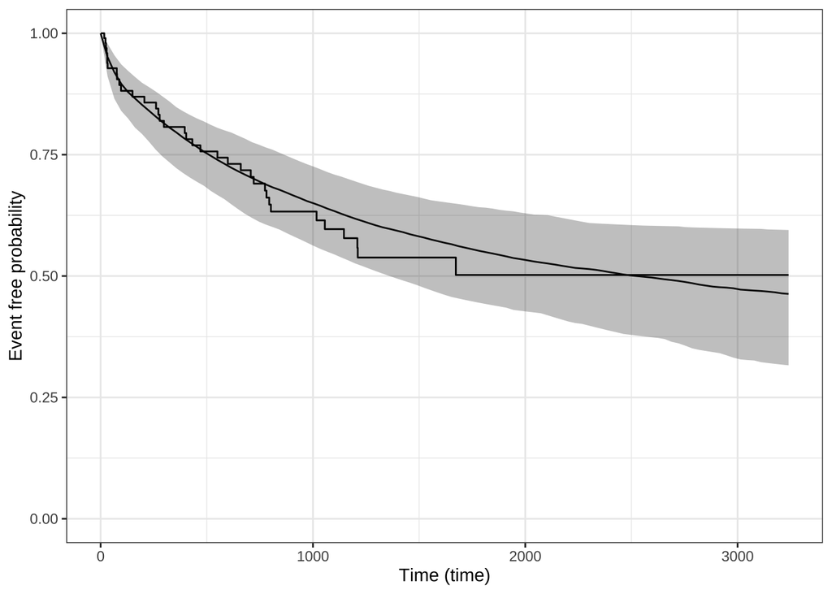

```r
ps_check(mod_sx) |>
  suppressWarnings()
```

### 2. Check performance of prior probability

```r
mod_sx_prior_only <- update(mod_sx, prior_PD = TRUE)
```

[output not shown]

[output not shown]

[output not shown]

[output not shown]

[output not shown]

[output not shown]

[output not shown]

[output not shown]

[output not shown]

[output not shown]

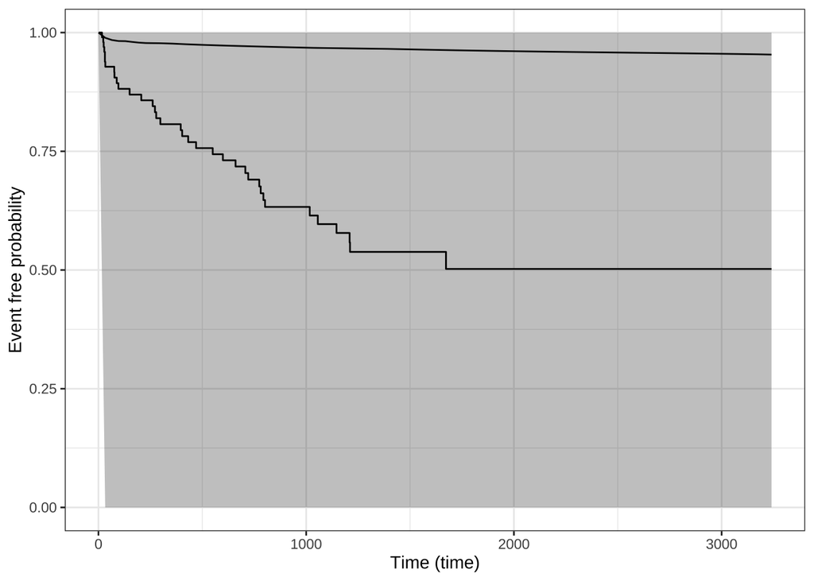

```r
ps_check(mod_sx_prior_only) |>
  suppressWarnings()
```

# V. Bayesian multi-level survival analysis for effect of PRESSURE GRADIENT (s_pv_max_pg) with random intercept for centre

## Set prior for beta variables

**Set an informative prior…**

student_t(df = 3, location = 0.687753, scale = 0.1460131)

```r
prior_beta_pg <- student_t(df = 3, location = 0.687753, scale = 0.1460131, autoscale = TRUE)
```

Based on the DAG, use the following adjustment variables: referral centre.

## Fit model with for s_pv_max_pg

NB use status … rstanarm requires the dead animals to be classified as 1, whilst censored are 0.

```r
mod_pg <- stan_surv(formula = Surv(time, status) ~ s_pv_max_pg
                      + (1| centre),
  data = df,
  basehaz = "ms",
  prior_intercept = normal(location = 0, scale = 12.5, autoscale = FALSE),
  prior = prior_beta_pg,
  prior_covariance =  decov(regularization = 2, concentration = 1, shape = 1, scale = 1),
  iter    = 12000,
  warmup = 4000,
  chains = 4,
  cores = 4,
  adapt_delta = 0.9999999,  # Often helpful for complex models
  seed = 666)
```

[output not shown]

[output not shown]

[output not shown]

[output not shown]

[output not shown]

[output not shown]

[output not shown]

[output not shown]

[output not shown]

[output not shown]

## Summarise priors from model

```r
prior_summary(mod_pg)
```

```
## Priors for model 'mod_pg'
## ------
## Intercept
##  ~ normal(location = 0, scale = 12)
##
## Coefficients
##   Specified prior:
##     ~ student_t(df = 3, location = 0.69, scale = 0.15)
##   Adjusted prior:
##     ~ student_t(df = 3, location = 0.69, scale = 0.15)
##
## Auxiliary (M-spline-coefficients)
##  ~ dirichlet(concentration = [1,1,1,...])
##
## Covariance
##  ~ decov(reg. = 2, conc. = 1, shape = 1, scale = 1)
## ------
## See help('prior_summary.stanreg') for more details
```

## Model summary

```r
summary(mod_pg)
```

```
##
## Model Info:
##
##  function:        stan_surv
##  baseline hazard: M-splines on hazard scale
##  formula:         Surv(time, status) ~ s_pv_max_pg + (1 | centre)
##  algorithm:       sampling
##  sample:          32000 (posterior sample size)
##  priors:          see help('prior_summary')
##  observations:    111
##  events:          37 (33.3%)
##  right censored:  74 (66.7%)
##  delayed entry:   no
##
## Estimates:
##                                         mean   sd   10%   50%   90%
## (Intercept)                           -0.2    0.4 -0.6  -0.2   0.3
## s_pv_max_pg                            0.2    0.2  0.0   0.2   0.5
## m-splines-coef1                        0.1    0.0  0.1   0.1   0.2
## m-splines-coef2                        0.1    0.1  0.0   0.1   0.2
## m-splines-coef3                        0.4    0.1  0.2   0.4   0.6
## m-splines-coef4                        0.2    0.1  0.0   0.2   0.4
## m-splines-coef5                        0.1    0.1  0.0   0.1   0.2
## m-splines-coef6                        0.1    0.1  0.0   0.1   0.2
## b[(Intercept) centre:p]               -0.1    0.4 -0.5   0.0   0.3
## b[(Intercept) centre:sath]             0.2    0.4 -0.1   0.1   0.7
## b[(Intercept) centre:willows]         -0.1    0.4 -0.5  -0.1   0.2
## Sigma[centre:(Intercept),(Intercept)]  0.4    1.0  0.0   0.1   0.9
##
## MCMC diagnostics
##                                       mcse Rhat n_eff
## (Intercept)                           0.0  1.0   9664
## s_pv_max_pg                           0.0  1.0  23573
## m-splines-coef1                       0.0  1.0  38287
## m-splines-coef2                       0.0  1.0  22420
## m-splines-coef3                       0.0  1.0  25627
## m-splines-coef4                       0.0  1.0  23054
## m-splines-coef5                       0.0  1.0  33391
## m-splines-coef6                       0.0  1.0  33282
## b[(Intercept) centre:p]               0.0  1.0  10693
## b[(Intercept) centre:sath]            0.0  1.0   9233
## b[(Intercept) centre:willows]         0.0  1.0   9561
## Sigma[centre:(Intercept),(Intercept)] 0.0  1.0  11879
## log-posterior                         0.0  1.0   8849
##
## For each parameter, mcse is Monte Carlo standard error, n_eff is a crude measure of effective sample size, and Rhat is the potential scale reduction factor on split chains (at convergence Rhat=1).
```

## Model short summary

```r
print(mod_pg, digits = 3)
```

```
## stan_surv
##  baseline hazard: M-splines on hazard scale
##  formula:         Surv(time, status) ~ s_pv_max_pg + (1 | centre)
##  observations:    111
##  events:          37 (33.3%)
##  right censored:  74 (66.7%)
##  delayed entry:   no
## ------
##                 Median MAD_SD exp(Median)
## (Intercept)     -0.185  0.329     NA
## s_pv_max_pg      0.229  0.181  1.257
## m-splines-coef1  0.106  0.044     NA
## m-splines-coef2  0.065  0.052     NA
## m-splines-coef3  0.427  0.145     NA
## m-splines-coef4  0.153  0.134     NA
## m-splines-coef5  0.077  0.077     NA
## m-splines-coef6  0.082  0.081     NA
##
## Error terms:
##  Groups Name        Std.Dev.
##  centre (Intercept) 0.6317
## Num. levels: centre 3
##
## ------
## * For help interpreting the printed output see ?print.stanreg
## * For info on the priors used see ?prior_summary.stanreg
```

## Plot Baseline hazard of model

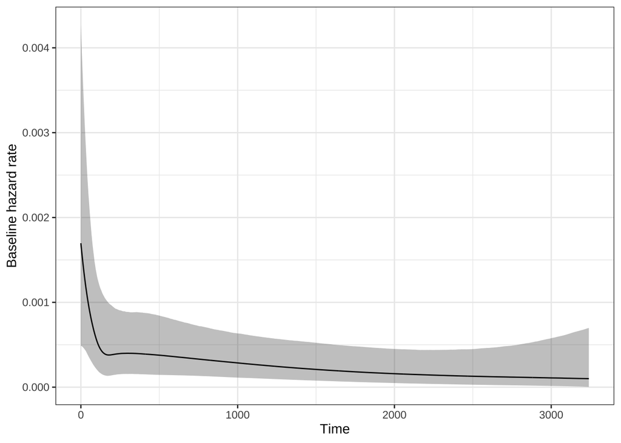

```r
plot(mod_pg)
```

## Plots of model convergences

## Get results

```r
posterior_mod_pg <- as.array(mod_pg)
```

### a. Check trace plots for model

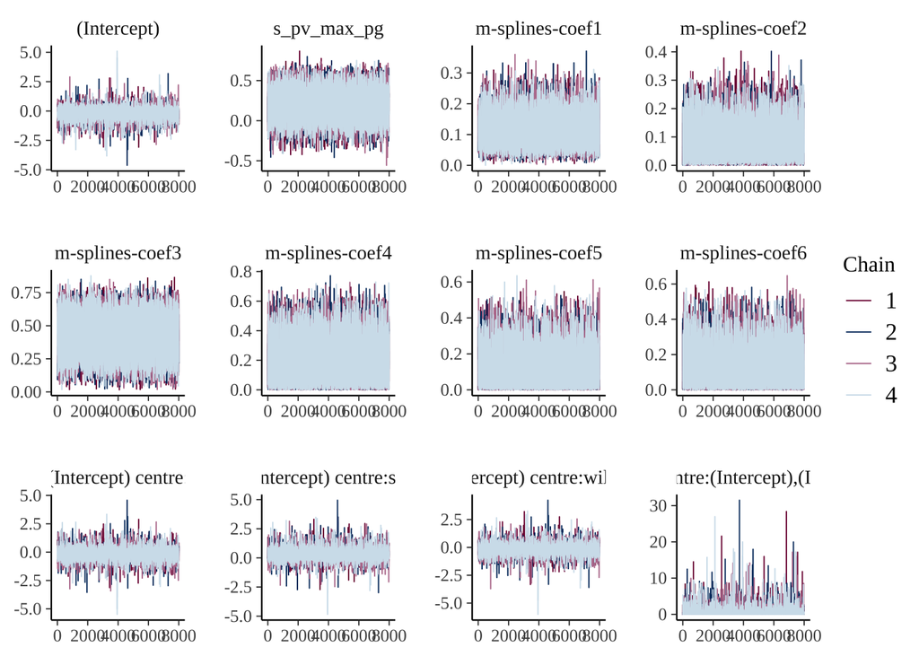

```r
color_scheme_set("mix-blue-pink")
mcmc_trace(posterior_mod_pg)
```

### b. Trace rank plot

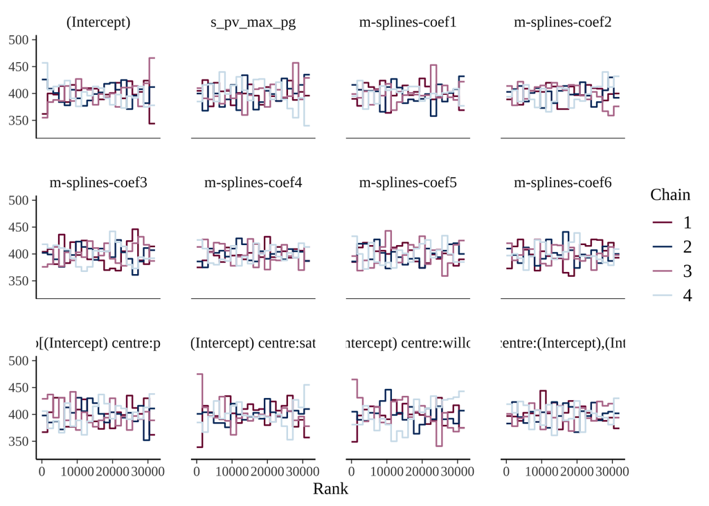

```r
color_scheme_set("mix-blue-pink")
mcmc_rank_overlay(posterior_mod_pg) +
  ylim(325, 500)
```

### c. get dens overlay plot for chains

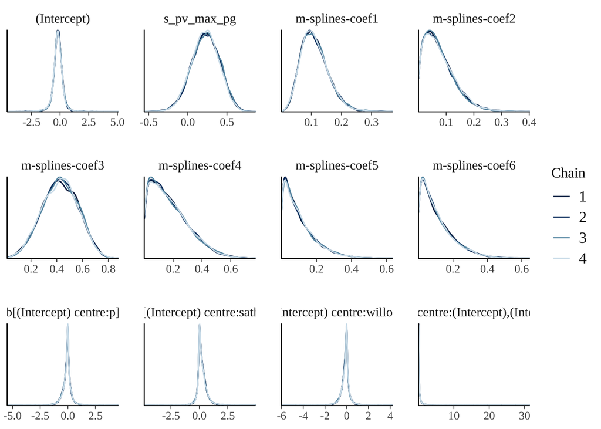

```r
color_scheme_set("blue")
mcmc_dens_overlay(posterior_mod_pg)
```

## Summaries of coefficients

### a. HPDI for the different beta parameters

```r
draws <- as.matrix(mod_pg)
median(draws[,2]) # draws for s_pv_max_pg
```

```
## [1] 0.2290007
```

```r
HPDI(draws[,2], 0.97) # draws for s_pv_max_pg
```

```
##      |0.97      0.97|
## -0.1572620  0.5977275
```

```r
HPDI(draws[,2], 0.89) # draws for s_pv_max_pg
```

```
##       |0.89       0.89|
## -0.05676401  0.50856801
```

### b. Hypothesis tests on beta parameters

#### s_pv_max_pg

probability that effect is positive

```r
mean(draws[,2] > 0) # draws for s_pv_max_pg
```

```
## [1] 0.895625
```

### c. Plot posterior distribution for beta coefficient of s_pv_max_pg

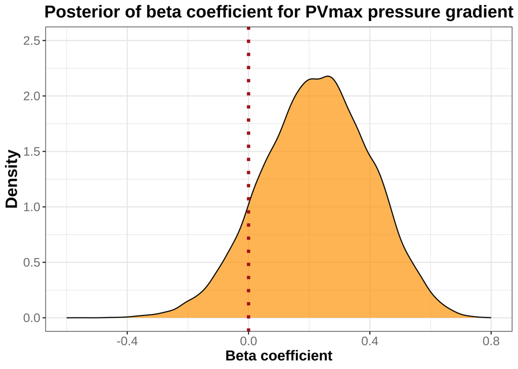

```r
s_pg <- draws[,2] # 2nd column is draws for s_pv_max_pg

ggplot(data.frame(s_pg), aes(x = s_pg)) +
  geom_density(fill = "orange", alpha = 0.7) +
  labs(title = "Posterior of beta coefficient for PVmax pressure gradient",
       x = "Beta coefficient",
       y = "Density") +
  theme_bw() +
           theme(axis.title.y = element_text(size=16, face="bold"),
               axis.title.x = element_text(size=14, face="bold"),
               title = element_text(size=14, face="bold"),
               plot.title = element_text(hjust = 0.5),
               axis.text.x = element_text(color = "grey50", size = 12),
               axis.text.y = element_text(color = "grey50",size = 12)) +
  geom_vline(xintercept = 0, linetype="dotted",
                color = "firebrick", linewidth = 1.5) +
  xlim(-0.6, 0.8) +
  ylim(0, 2.5)
```

## Get HDI for coefficients

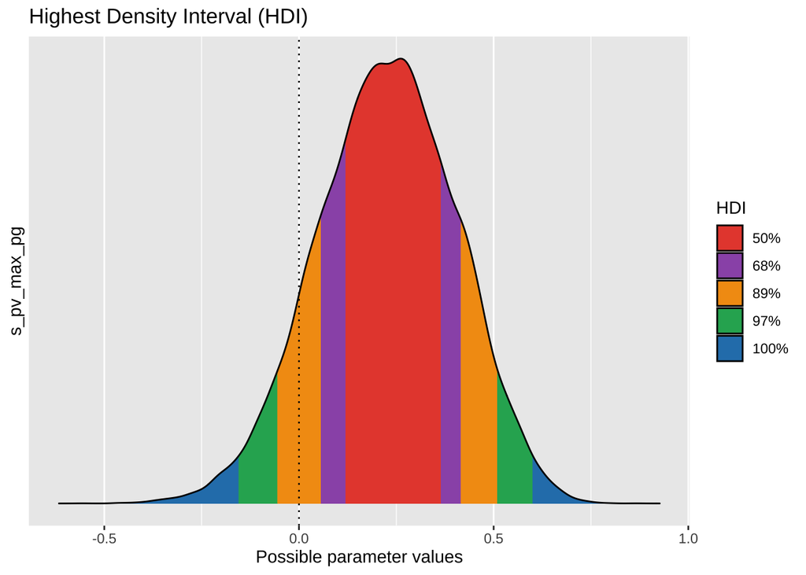

```r
hdi <- bayestestR::hdi(mod_pg, ci = c(0.50, 0.68, 0.89, 0.97), parameters = "s_pv_max_pg")
plot(hdi)
```

## Get density plots for posterior distributons of beta parameters

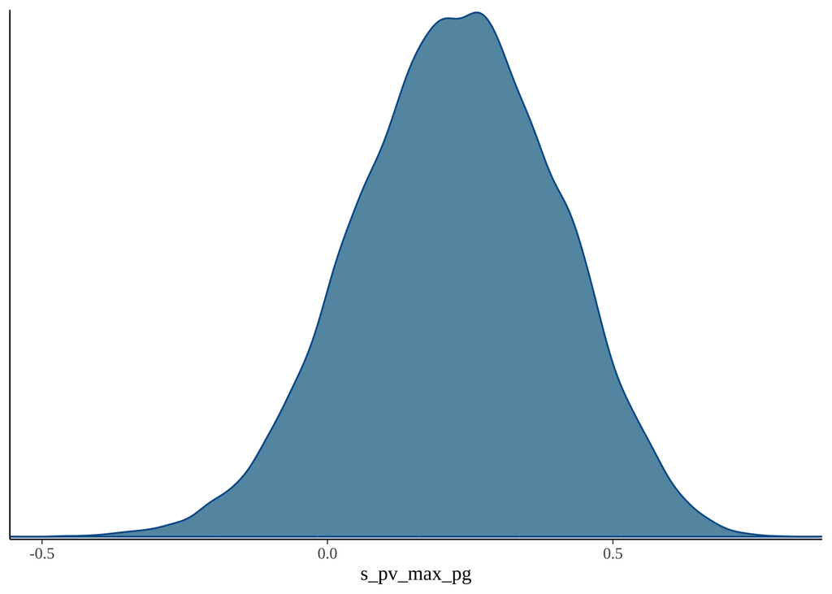

```r
mcmc_dens(posterior_mod_pg,
  pars = c("s_pv_max_pg"))
```

## Get area plot for posterior distributons of beta parameters

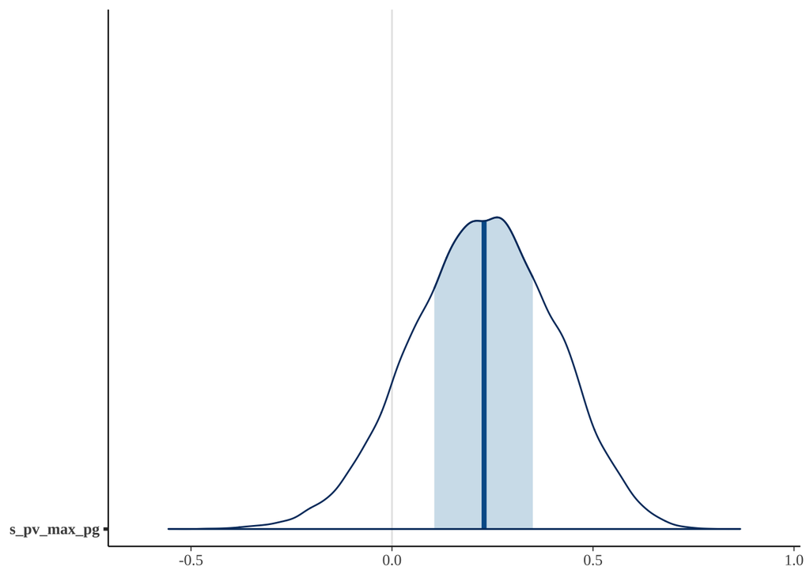

```r
mcmc_areas(posterior_mod_pg,
  pars = "s_pv_max_pg")
```

## Calculate hazard ratios for s_pv_max_pg

### a. get posterior draws

```r
s_pv_max_pg_hr <- exp(draws[,2]) # draws for s_pv_max_pg)
```

### b. Summarise hazard ratios for s_pv_max_pg

```r
median(s_pv_max_pg_hr)
```

```
## [1] 1.257343
```

```r
hpdi_s_pv_max_pg_hr <- HPDI(s_pv_max_pg_hr, prob = c(0.89, 0.97))
hpdi_s_pv_max_pg_hr
```

```
##     |0.97     |0.89     0.89|     0.97|
## 0.8264515 0.9088737 1.6155036 1.7769538
```

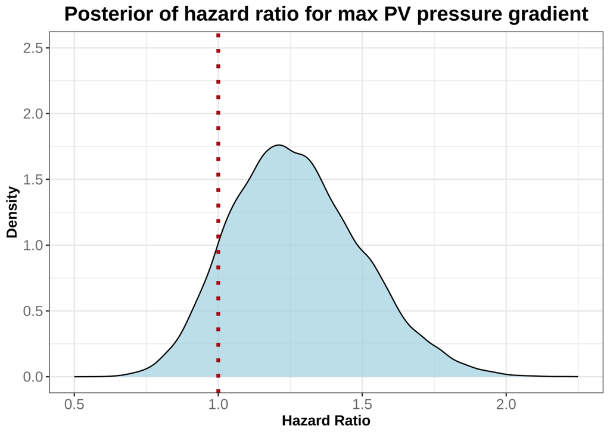

```r
ggplot(data.frame(s_pv_max_pg_hr), aes(x = s_pv_max_pg_hr)) +
  geom_density(fill = "lightblue", alpha = 0.7) +
  labs(title = "Posterior of hazard ratio for max PV pressure gradient",
       x = "Hazard Ratio",
       y = "Density") +
  theme_bw() +
           theme(axis.title.y = element_text(size=12, face="bold"),
               axis.title.x = element_text(size=12, face="bold"),
               title = element_text(size=14, face="bold"),
               plot.title = element_text(hjust = 0.5),
               axis.text.x = element_text(color = "grey50", size = 12),
               axis.text.y = element_text(color = "grey50",size = 12)) +
  geom_vline(xintercept = 1, linetype="dotted",
                color = "firebrick", linewidth = 1.5) +
  xlim(0.5, 2.25) +
  ylim(0, 2.5)
```

## Check model performance

### 1. Check performance of posterior probability

NB equivalent of pp_check

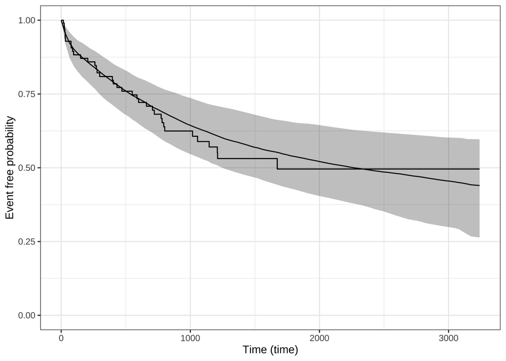

```r
ps_check(mod_pg) |>
  suppressWarnings()
```

### 2. Check performance of prior probability

```r
mod_pg_prior_only <- update(mod_pg, prior_PD = TRUE)
```

[output not shown]

[output not shown]

[output not shown]

[output not shown]

[output not shown]

[output not shown]

[output not shown]

[output not shown]

[output not shown]

[output not shown]

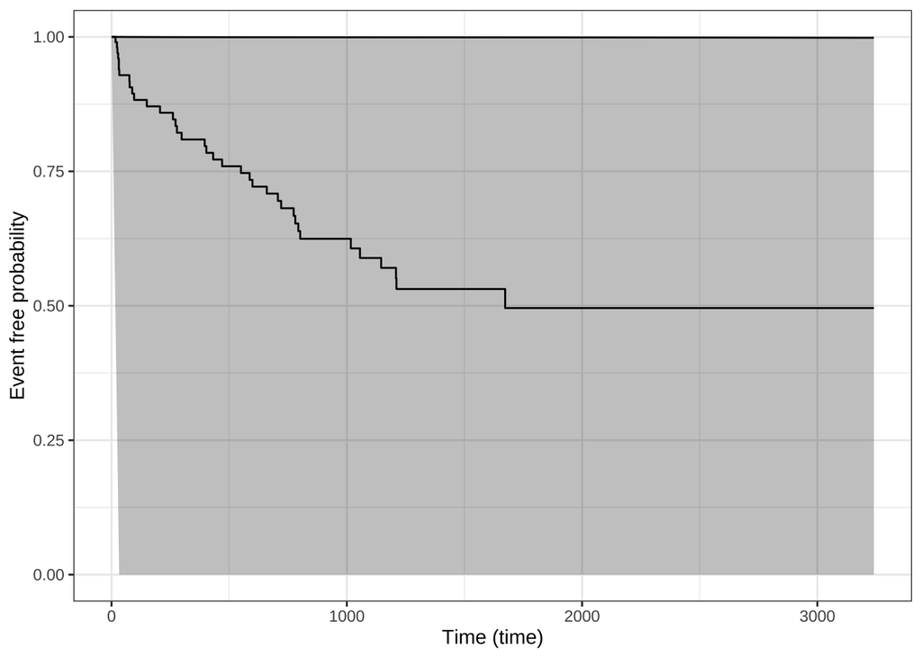

```r
ps_check(mod_pg_prior_only) |>
  suppressWarnings()
```

### 3. Check posterior vs prior for beta variable

#### a. extract draws for posterior and prior

```r
# extract draws
post_draws  <- as.matrix(mod_pg)
prior_draws <- as.matrix(mod_pg_prior_only)
```

#### b. plot marginal distributions for posterior and prior

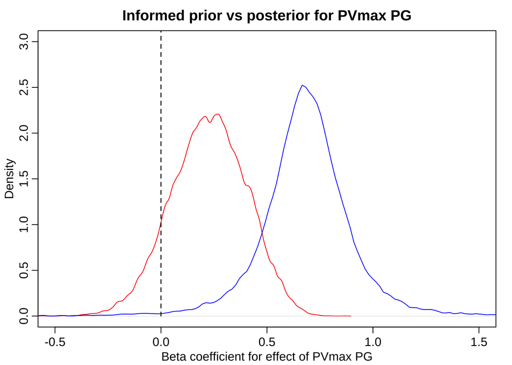

```r
# Compare marginal distributions
dens(post_draws[, "s_pv_max_pg"], show.zero = TRUE, col = "red", main = "Informed prior vs posterior for PVmax PG", xlab = "Beta coefficient for effect of PVmax PG",, xlim = c(-0.5, 1.5), ylim = c(0, 3.0))
dens(prior_draws[, "s_pv_max_pg"], add=TRUE, col = "blue", show.zero = TRUE)
```

#### c. compute prior tail probability of posterior mean

If this probability is very small (e.g. < 0.05), the posterior lies in a region the prior considered implausible.

```r
beta_hat <- mean(post_draws[, "s_pv_max_pg"])

mean(abs(prior_draws[, "s_pv_max_pg"] - beta_hat) <
       abs(prior_draws[, "s_pv_max_pg"] - mean(prior_draws[, "s_pv_max_pg"])))
```

```
## [1] 0.1056875
```

### 4. Sensitivity analyses to assess robustness of results to choice of prior

#### a. create priors of different strength for s_pv_max_pg variable

To determine whether the substantive conclusions depend upon the exact prior choice.

NB the scale variable is strengthened or weakened by multiplying or dividing the scale of the main prior by 2, respectively. The location is set to the posterior mean from the main model, to ensure that the priors are centred on a plausible value.

```r
priors_bin <- list(
  weak = student_t(df = 3, location = 0.687753, scale = (0.5840526), autoscale = FALSE),
  moderate = student_t(df = 3, location = 0.687753, scale = (0.2920263), autoscale = FALSE),
  strong = student_t(df = 3, location = 0.687753, scale = (0.1460131), autoscale = FALSE)
)
```

**Set an informative, regularising prior…**

student_t(df = 3, location = 0.687753, scale = 0.1460131) NB set at 0.5 given that ther scale is so small, to ensure that the data are not overwhelmed by the prior, but still allow for some regularisation to improve model convergence and reduce overfitting.

strong 0.1460131 moderate 0.2920263 weak 0.5840526

#### b. refit model with different priors and compare results

```r
fits <- lapply(priors_bin, function(p) {
  stan_surv(formula = Surv(time, status) ~ s_pv_max_pg
            + (1| centre),
            basehaz = "ms",
            data = df,
            prior_intercept = normal(location = 0, scale = 20, autoscale = FALSE),
            prior = p,
            prior_covariance =  decov(regularization = 2, concentration = 1, shape = 1, scale = 1),
            iter    = 2000,
            chains = 4,
            cores = 4,
            adapt_delta = 0.9999,  # Often helpful for complex models
            seed = 666
            )
})
```

[output not shown]

[output not shown]

[output not shown]

[output not shown]

[output not shown]

[output not shown]

[output not shown]

[output not shown]

[output not shown]

[output not shown]

[output not shown]

[output not shown]

[output not shown]

[output not shown]

[output not shown]

[output not shown]

[output not shown]

[output not shown]

[output not shown]

[output not shown]

[output not shown]

[output not shown]

[output not shown]

[output not shown]

[output not shown]

[output not shown]

[output not shown]

[output not shown]

#### c. compare posterior intervals for hazard ratios for pg across different priors

```r
# calculate median hazard ratio across different priors
HR_med_sens <- sapply(fits, function(f) {
  posterior::as_draws_df(f) |>
    as.data.frame() |>
    summarise(
      median = exp(quantile(s_pv_max_pg, probs = 0.5))
    )
})
HR_med <- c(HR_med_sens[[1]], HR_med_sens[[2]], HR_med_sens[[3]])


# calculate 89% credible interval for hazard ratio across different priors
HR_sens <- sapply(fits, function(f) {
  exp(posterior_interval(f, pars = "s_pv_max_pg", prob = 0.89))
})

# combine median and credible intervals into a summary table
HR_sens_summary <- rbind(HR_med, HR_sens)
row.names(HR_sens_summary) <- c("Median", "Lower", "Upper")

# transpose the table for better readability
HR_sens_summary
```

```
##            weak  moderate   strong
## Median 1.106857 1.1698866 1.263646
## Lower  0.837764 0.8921128 0.946481
## Upper  1.437920 1.5138493 1.657862
```

### 1. Create new data where s_pv_max_pg differs

```r
nd <- data.frame(centre = rep("p", 5),
                 s_pv_max_pg = c(-1.7, -0.76, 0, 0.88, 1.9)
                 )
head(nd)
```

```
##   centre s_pv_max_pg
## 1      p       -1.70
## 2      p       -0.76
## 3      p        0.00
## 4      p        0.88
## 5      p        1.90
```

### 2. Make posterior predictions from new data

```r
ps <- posterior_survfit(mod_pg,
  newdata = nd,
  times = 0,
  extrapolate = TRUE) |>
  suppressWarnings()
head(ps)
```

```
## stan_surv predictions
##  num. individuals: 5
##  prediction type:  event free probability
##  standardised?:    no
##  conditional?:     no
##
##   id cond_time     time median  ci_lb  ci_ub
## 1  1        NA   0.0000 1.0000 1.0000 1.0000
## 2  1        NA  32.7273 0.9705 0.9235 0.9914
## 3  1        NA  65.4545 0.9506 0.8772 0.9846
## 4  1        NA  98.1818 0.9370 0.8436 0.9792
## 5  1        NA 130.9091 0.9263 0.8249 0.9748
## 6  1        NA 163.6364 0.9173 0.8096 0.9713
```

### 3. Plot

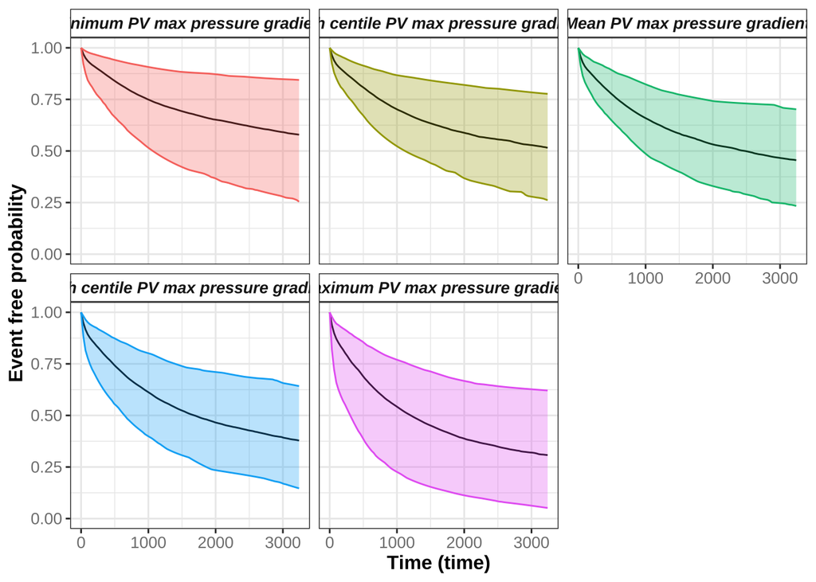

```r
panel_labels <- c('1' = "Minimum PV max pressure gradient",
                  '2' = "25th centile PV max pressure gradient",
                  '3' = "Mean PV max pressure gradient",
                  '4' = "75th centile PV max pressure gradient",
                  '5' = "Maximum PV max pressure gradient")
pps <- plot(ps) +
  aes(colour = factor(id), fill = factor(id)) +
  theme(legend.position = "none") +
  facet_wrap(~ id, labeller = labeller(id = panel_labels)) +
           theme(axis.title.y = element_text(size=12, face="bold"),
               axis.title.x = element_text(size=12, face="bold"),
               title = element_text(size=12, face="bold"),
               plot.title = element_text(hjust = 0.5),
               axis.text.x = element_text(color = "grey50", size = 10),
               axis.text.y = element_text(color = "grey50",size = 10)) +
            theme(strip.text.x = element_text(size = 10, face = "bold.italic"),
                   strip.background = element_rect(fill="white")
        )

print(pps)
```

## Check PH assumption visually

### make predictions of both the hazard and log hazard

```r
ph <- suppressWarnings(posterior_survfit(mod_pg, newdata = nd, type = "haz"))
pl <- suppressWarnings(posterior_survfit(mod_pg, newdata = nd, type = "loghaz"))
```

#### create plots

```r
pph <- plot(ph) +
  facet_wrap(~ id, labeller = labeller(id = panel_labels))
ppl <- plot(pl) +
  facet_wrap(~ id, labeller = labeller(id = panel_labels))
```

#### combine plots in grid and plot

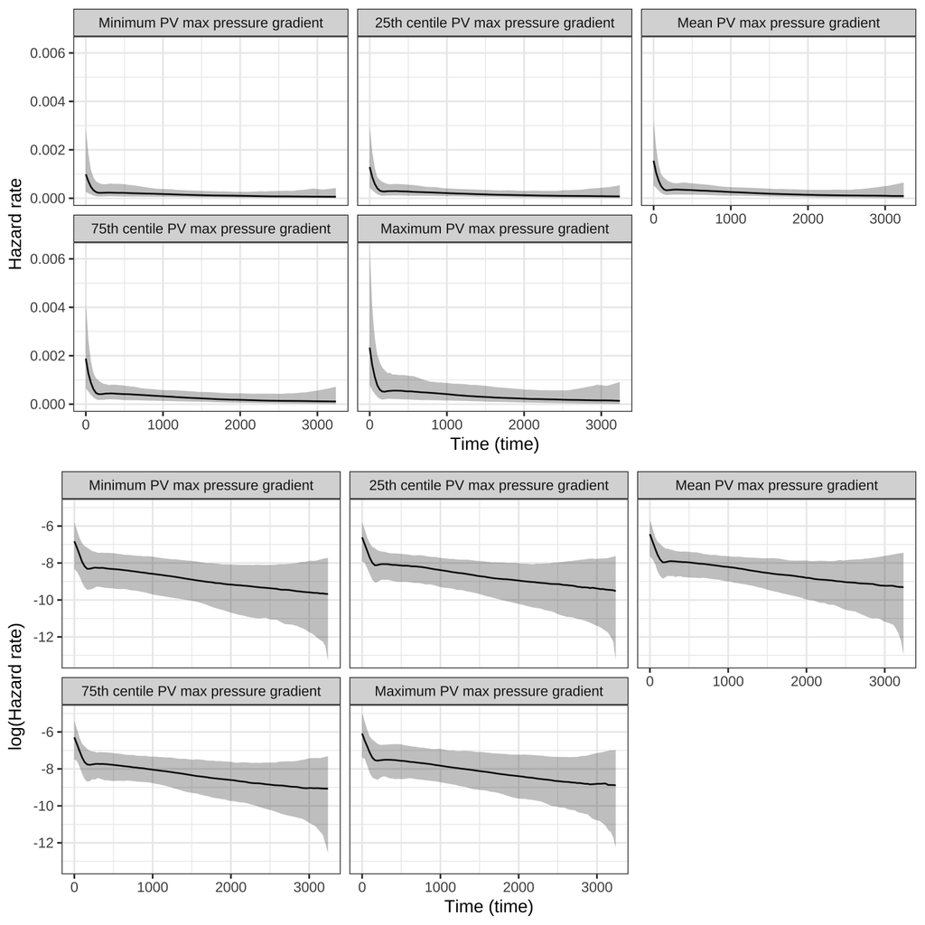

```r
plot_grid(pph, ppl, ncol = 1)
```

# X. Bayesian multi-level survival analysis for effect of RIGHT CHF with random intercept for centre

## Set prior for beta variables

**Set an informative prior…**

student_t(df = 3, location = 1.57583, scale = 0.7705384)

```r
prior_beta_chf <- student_t(df = 3, location = c(1.57583, 0, 0, 0, 0, 0, 0),
                            scale = c(0.7705384, 2, 2, 2, 2, 2, 2),
                            autoscale = c(FALSE, FALSE, FALSE, FALSE, TRUE, TRUE, FALSE))
```

Based on the DAG, use the following adjustment variables: RV syst dys, arrhyth, concurrent congen, pressure grad, referral centre, stenosis type

## Fit model

NB use status … rstanarm requires the dead animals to be classified as 1, whilst censored are 0.

```r
mod_chf <- stan_surv(formula = Surv(time, status) ~ chf
                     + concurrent_congenital
                     + type
                     + s_tapse
                     + s_pv_max_pg
                     + arrhythmias
                     + (1| centre),
  data = df,
  basehaz = "ms",
  prior_intercept = normal(location = 0, scale = 20, autoscale = FALSE),
  prior = prior_beta_chf,
  prior_covariance =  decov(regularization = 2, concentration = 1, shape = 1, scale = 1),
  iter    = 12000,
  warmup = 4000,
  chains = 4,
  cores = 4,
  adapt_delta = 0.999999,  # Often helpful for complex models
  seed = 666)
```

[output not shown]

[output not shown]

[output not shown]

[output not shown]

[output not shown]

[output not shown]

[output not shown]

[output not shown]

[output not shown]

[output not shown]

## Summarise priors from model

```r
prior_summary(mod_chf)
```

```
## Priors for model 'mod_chf'
## ------
## Intercept
##  ~ normal(location = 0, scale = 20)
##
## Coefficients
##  ~ student_t(df = [3,3,3,...], location = [1.6,0.0,0.0,...], scale = [0.77,2.00,2.00,...])
##
## Auxiliary (M-spline-coefficients)
##  ~ dirichlet(concentration = [1,1,1,...])
##
## Covariance
##  ~ decov(reg. = 2, conc. = 1, shape = 1, scale = 1)
## ------
## See help('prior_summary.stanreg') for more details
```

## Model summary

```r
summary(mod_chf)
```

```
##
## Model Info:
##
##  function:        stan_surv
##  baseline hazard: M-splines on hazard scale
##  formula:         Surv(time, status) ~ chf + concurrent_congenital + type + s_tapse +
##     s_pv_max_pg + arrhythmias + (1 | centre)
##  algorithm:       sampling
##  sample:          32000 (posterior sample size)
##  priors:          see help('prior_summary')
##  observations:    80
##  events:          27 (33.8%)
##  right censored:  53 (66.2%)
##  delayed entry:   no
##
## Estimates:
##                                         mean   sd   10%   50%   90%
## (Intercept)                           -0.9    0.6 -1.6  -0.9  -0.2
## chf1                                   1.4    0.5  0.8   1.4   2.0
## concurrent_congenital1                 0.6    0.5  0.0   0.6   1.2
## typeb                                 -0.3    0.7 -1.2  -0.2   0.6
## typeintermediate                       0.6    0.4  0.0   0.6   1.2
## s_tapse                               -0.2    0.3 -0.5  -0.2   0.2
## s_pv_max_pg                           -0.2    0.2 -0.5  -0.2   0.0
## arrhythmias1                          -0.7    0.7 -1.5  -0.7   0.1
## m-splines-coef1                        0.1    0.0  0.0   0.1   0.1
## m-splines-coef2                        0.1    0.0  0.0   0.0   0.1
## m-splines-coef3                        0.4    0.2  0.2   0.4   0.6
## m-splines-coef4                        0.2    0.2  0.0   0.2   0.4
## m-splines-coef5                        0.1    0.1  0.0   0.1   0.3
## m-splines-coef6                        0.1    0.1  0.0   0.1   0.3
## b[(Intercept) centre:p]               -0.1    0.5 -0.7  -0.1   0.3
## b[(Intercept) centre:sath]             0.2    0.5 -0.2   0.1   0.8
## b[(Intercept) centre:willows]         -0.1    0.4 -0.5   0.0   0.3
## Sigma[centre:(Intercept),(Intercept)]  0.5    1.2  0.0   0.1   1.1
##
## MCMC diagnostics
##                                       mcse Rhat n_eff
## (Intercept)                           0.0  1.0  17414
## chf1                                  0.0  1.0  22735
## concurrent_congenital1                0.0  1.0  24931
## typeb                                 0.0  1.0  26164
## typeintermediate                      0.0  1.0  27423
## s_tapse                               0.0  1.0  28356
## s_pv_max_pg                           0.0  1.0  26327
## arrhythmias1                          0.0  1.0  24320
## m-splines-coef1                       0.0  1.0  44137
## m-splines-coef2                       0.0  1.0  26322
## m-splines-coef3                       0.0  1.0  32703
## m-splines-coef4                       0.0  1.0  29996
## m-splines-coef5                       0.0  1.0  40975
## m-splines-coef6                       0.0  1.0  37706
## b[(Intercept) centre:p]               0.0  1.0  16963
## b[(Intercept) centre:sath]            0.0  1.0  12614
## b[(Intercept) centre:willows]         0.0  1.0  14068
## Sigma[centre:(Intercept),(Intercept)] 0.0  1.0  19433
## log-posterior                         0.0  1.0  11320
##
## For each parameter, mcse is Monte Carlo standard error, n_eff is a crude measure of effective sample size, and Rhat is the potential scale reduction factor on split chains (at convergence Rhat=1).
```

## Model short summary

```r
print(mod_chf, digits = 3)
```

```
## stan_surv
##  baseline hazard: M-splines on hazard scale
##  formula:         Surv(time, status) ~ chf + concurrent_congenital + type + s_tapse +
##     s_pv_max_pg + arrhythmias + (1 | centre)
##  observations:    80
##  events:          27 (33.8%)
##  right censored:  53 (66.2%)
##  delayed entry:   no
## ------
##                        Median MAD_SD exp(Median)
## (Intercept)            -0.864  0.557     NA
## chf1                    1.438  0.473  4.211
## concurrent_congenital1  0.601  0.480  1.825
## typeb                  -0.239  0.671  0.787
## typeintermediate        0.579  0.443  1.785
## s_tapse                -0.175  0.266  0.840
## s_pv_max_pg            -0.237  0.221  0.789
## arrhythmias1           -0.657  0.642  0.518
## m-splines-coef1         0.068  0.037     NA
## m-splines-coef2         0.041  0.038     NA
## m-splines-coef3         0.391  0.163     NA
## m-splines-coef4         0.180  0.160     NA
## m-splines-coef5         0.103  0.100     NA
## m-splines-coef6         0.107  0.103     NA
##
## Error terms:
##  Groups Name        Std.Dev.
##  centre (Intercept) 0.6745
## Num. levels: centre 3
##
## ------
## * For help interpreting the printed output see ?print.stanreg
## * For info on the priors used see ?prior_summary.stanreg
```

## Plot Baseline hazard of model

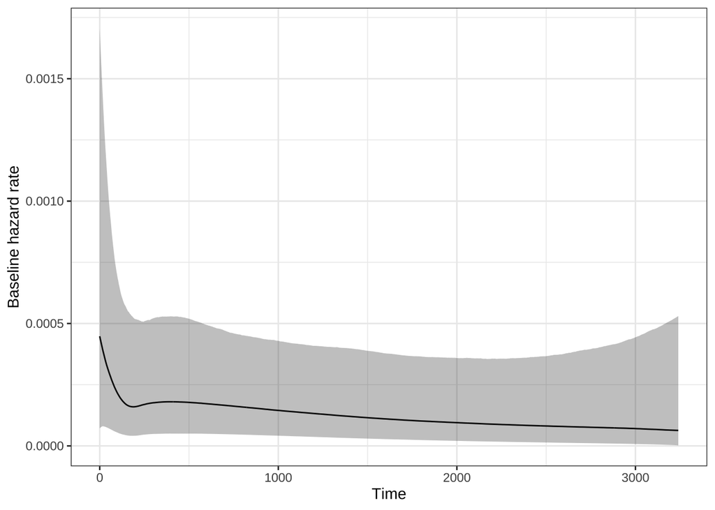

```r
plot(mod_chf)
```

## Plots of model convergences

## Get results

```r
posterior_mod_chf <- as.array(mod_chf)
```

### a. Check trace plots for model

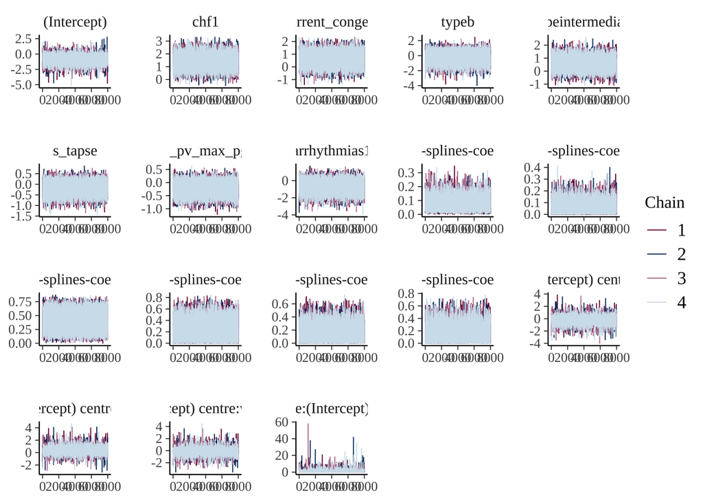

```r
color_scheme_set("mix-blue-pink")
mcmc_trace(posterior_mod_chf)
```

### b. Trace rank plot

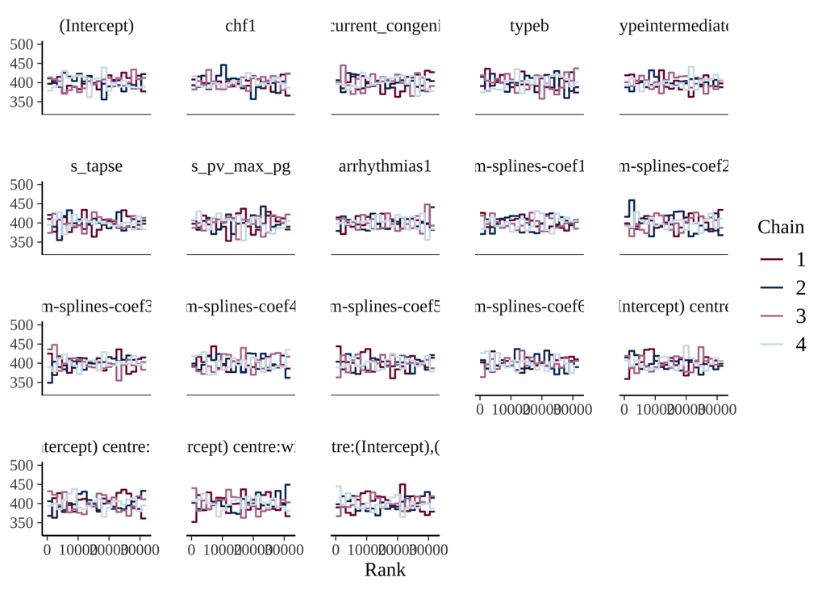

```r
color_scheme_set("mix-blue-pink")
mcmc_rank_overlay(posterior_mod_chf) +
  ylim(325, 500)
```

### c. get dens overlay plot for chains

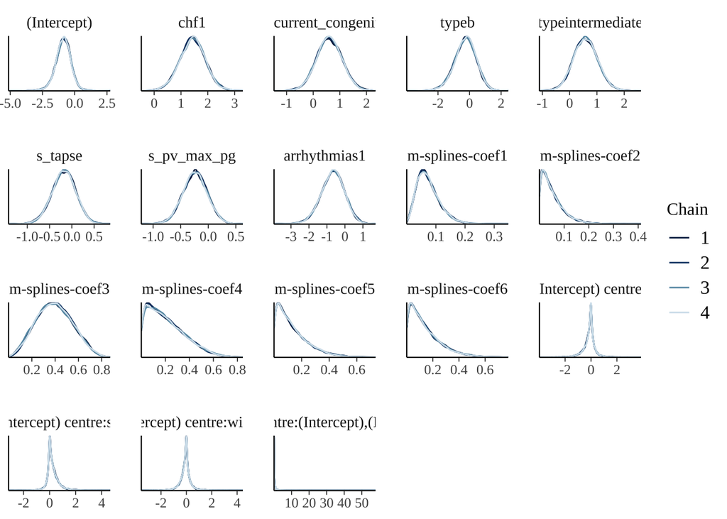

```r
color_scheme_set("blue")
mcmc_dens_overlay(posterior_mod_chf)
```

## Summaries of coefficients

### a. HPDI for the different beta parameters

```r
draws <- as.matrix(mod_chf)
median(draws[,2]) # draws for chf
```

```
## [1] 1.43771
```

```r
HPDI(draws[,2], 0.97) # draws for chf
```

```
##     |0.97     0.97|
## 0.3272036 2.4574162
```

```r
HPDI(draws[,2], 0.89) # draws for chf
```

```
##     |0.89     0.89|
## 0.6521354 2.1827332
```

### b. Hypothesis tests on beta parameters

#### chf

probability that effect is positive

```r
mean(draws[,2] > 0) # draws for chf
```

```
## [1] 0.9979375
```

### c. Plot posterior distribution for beta coefficient of chf

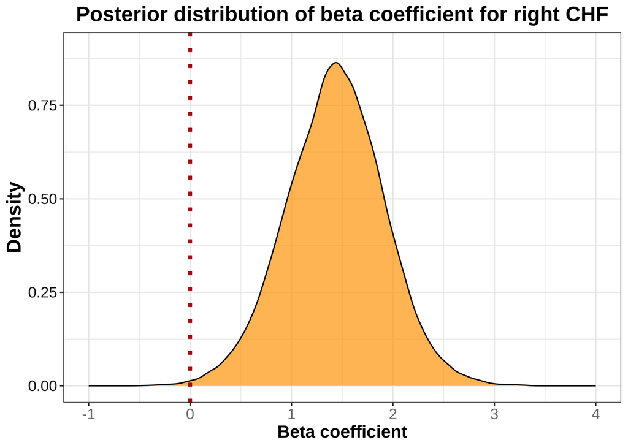

```r
s_chf <- draws[,2] # 2nd column is draws for chf

ggplot(data.frame(s_chf), aes(x = s_chf)) +
  geom_density(fill = "orange", alpha = 0.7) +
  labs(title = "Posterior distribution of beta coefficient for right CHF",
       x = "Beta coefficient",
       y = "Density") +
  theme_bw() +
           theme(axis.title.y = element_text(size=16, face="bold"),
               axis.title.x = element_text(size=14, face="bold"),
               title = element_text(size=14, face="bold"),
               plot.title = element_text(hjust = 0.5),
               axis.text.x = element_text(color = "grey50", size = 12),
               axis.text.y = element_text(color = "grey8",size = 12)) +
  geom_vline(xintercept = 0, linetype="dotted",
                color = "firebrick", linewidth = 1.5) +
  xlim(-1, 4) +
  ylim(0, 0.9)
```

## Get HDI for coefficients

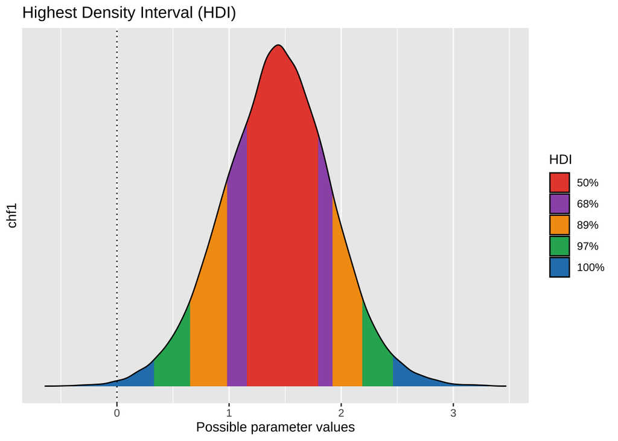

```r
hdi <- bayestestR::hdi(mod_chf, ci = c(0.50, 0.68, 0.89, 0.97), parameters = "chf")
plot(hdi)
```

## Get density plots for posterior distributons of beta parameters

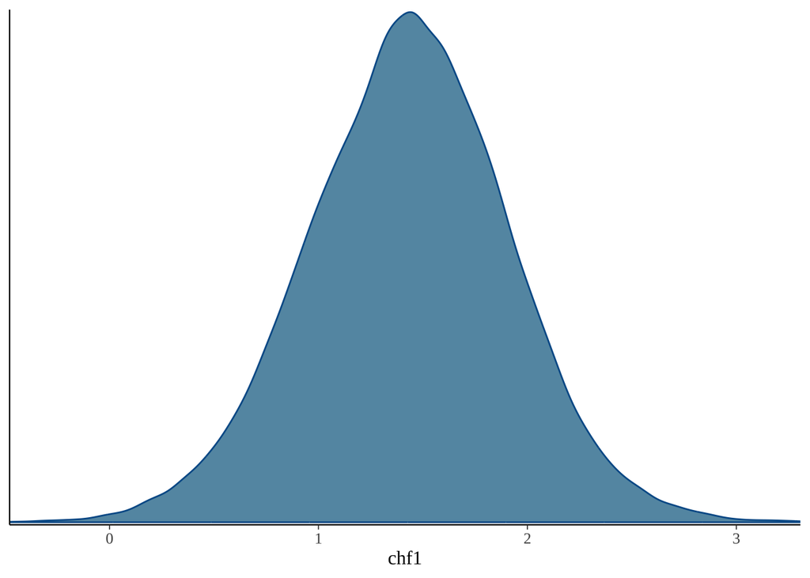

```r
mcmc_dens(posterior_mod_chf,
  pars = c("chf1"))
```

## Get area plot for posterior distributons of beta parameters

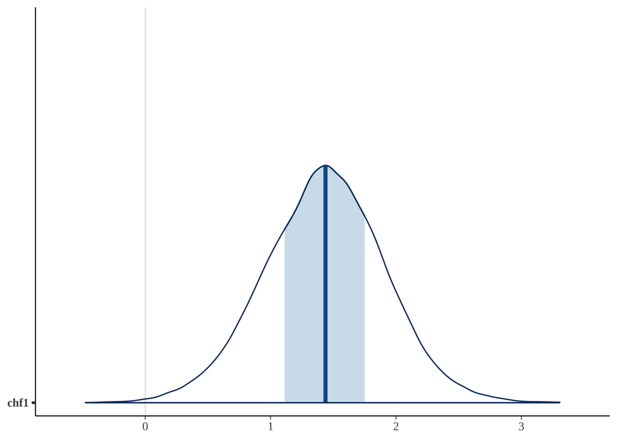

```r
mcmc_areas(posterior_mod_chf,
  pars = "chf1")
```

## Calculate hazard ratios for chf

### a. get posterior draws

```r
chf_hr <- exp(draws[,2]) # 2nd column is draws for chf)
```

### b. Summarise hazard ratios for chf

```r
median(chf_hr)
```

```
## [1] 4.21104
```

```r
hpdi_chf_hr <- HPDI(chf_hr, prob = c(0.89, 0.97))
hpdi_chf_hr
```

```
##      |0.97      |0.89      0.89|      0.97|
##  0.9609904  1.3856029  7.7018866 10.4433310
```

### c. Plot posterior distribution for hazard ratio of chf

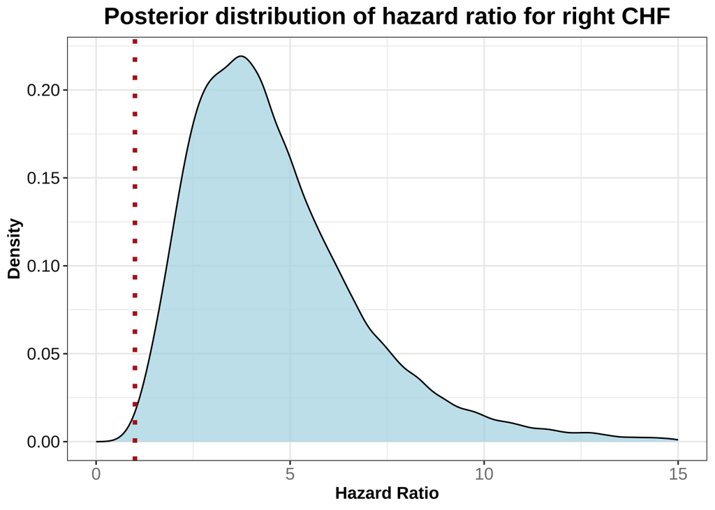

```r
ggplot(data.frame(chf_hr), aes(x = chf_hr)) +
  geom_density(fill = "lightblue", alpha = 0.7) +
  labs(title = "Posterior distribution of hazard ratio for right CHF",
       x = "Hazard Ratio",
       y = "Density") +
  theme_bw() +
           theme(axis.title.y = element_text(size=12, face="bold"),
               axis.title.x = element_text(size=12, face="bold"),
               title = element_text(size=14, face="bold"),
               plot.title = element_text(hjust = 0.5),
               axis.text.x = element_text(color = "grey50", size = 12),
               axis.text.y = element_text(color = "grey8",size = 12)) +
  geom_vline(xintercept = 1, linetype="dotted",
                color = "firebrick", linewidth = 1.5) +
  xlim(0, 15)
```

## Check model performance

### 1. Check performance of posterior probability

NB equivalent of pp_check

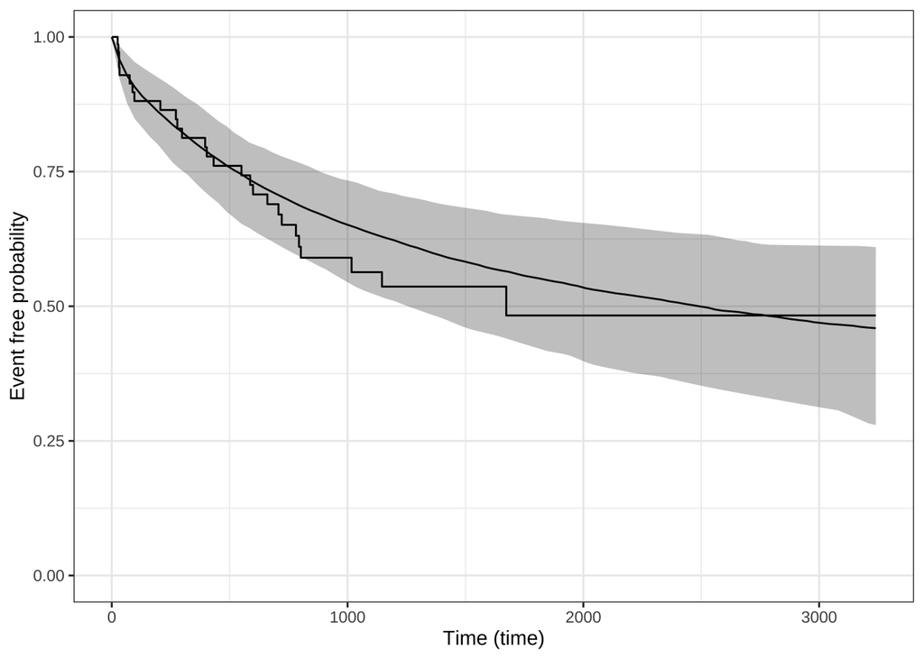

```r
ps_check(mod_chf) |>
  suppressWarnings()
```

### 2. Check performance of prior probability

```r
mod_chf_prior_only <- update(mod_chf, prior_PD = TRUE)
```

[output not shown]

[output not shown]

[output not shown]

[output not shown]

[output not shown]

[output not shown]

[output not shown]

[output not shown]

[output not shown]

[output not shown]

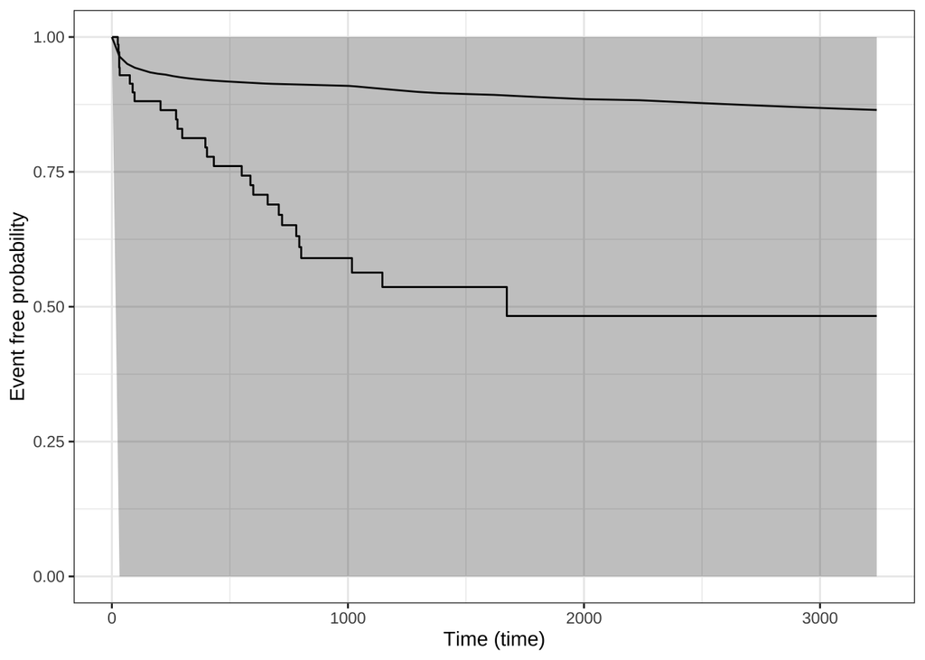

```r
ps_check(mod_chf_prior_only) |>
  suppressWarnings()
```

### 3. Check posterior vs prior for beta variable

#### a. extract draws for posterior and prior

```r
# extract draws
post_draws  <- as.matrix(mod_chf)
prior_draws <- as.matrix(mod_chf_prior_only)
```

#### b. plot marginal distributions for posterior and prior

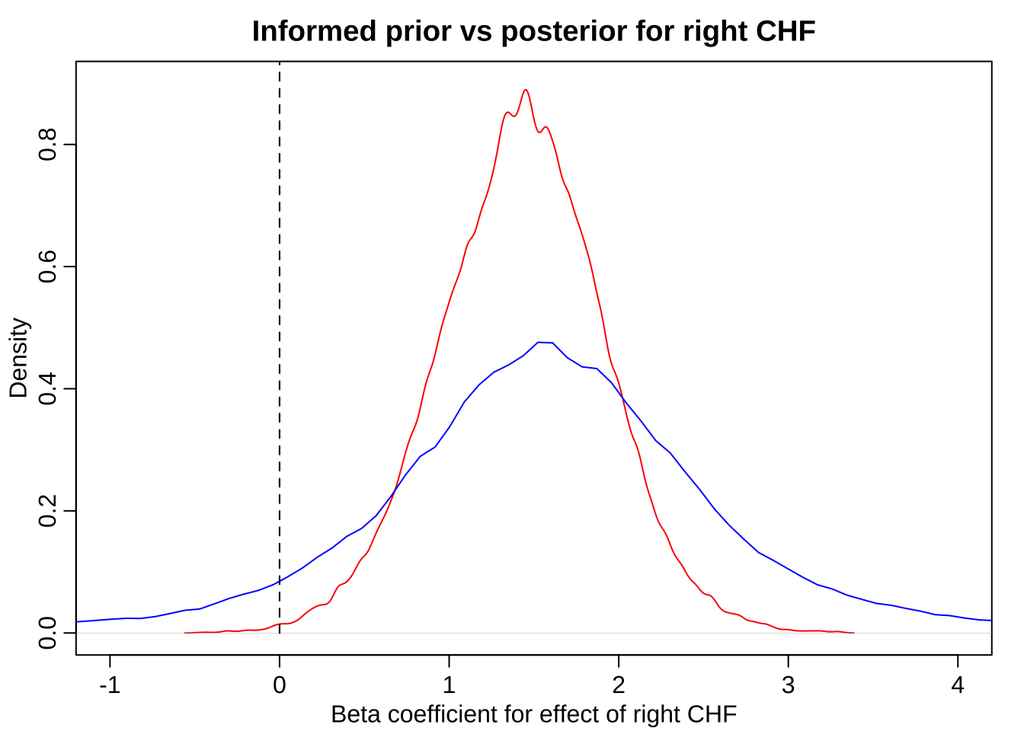

```r
# Compare marginal distributions
dens(post_draws[, "chf1"], show.zero = TRUE, col = "red", main = "Informed prior vs posterior for right CHF",
     xlab = "Beta coefficient for effect of right CHF", xlim = c(-1, 4), ylim = c(0, 0.9))
dens(prior_draws[, "chf1"], add=TRUE, col = "blue", show.zero = TRUE)
```

#### c. compute prior tail probability of posterior mean

If this probability is very small (e.g. < 0.05), the posterior lies in a region the prior considered implausible.

```r
beta_hat <- mean(post_draws[, "chf1"])

mean(abs(prior_draws[, "chf1"] - beta_hat) <
       abs(prior_draws[, "chf1"] - mean(prior_draws[, "chf1"])))
```

```
## [1] 0.4677812
```

### 4. Sensitivity analyses to assess robustness of results to choice of prior

To determine whether the substantive conclusions depend upon the exact prior choice.

```r
priors_bin <- list(
  weak = student_t(df = 3, location = c(1.57583, 0, 0, 0, 0, 0, 0),
                   scale = c(3.0821537, 2, 2, 2, 2, 2, 2),
                   autoscale = c(FALSE, FALSE, FALSE, FALSE, TRUE, TRUE, FALSE)),
  moderate = student_t(df = 3, location = c(1.57583, 0, 0, 0, 0, 0, 0),
                       scale = c(1.5410768, 2, 2, 2, 2, 2, 2),
                       autoscale = c(FALSE, FALSE, FALSE, FALSE, TRUE, TRUE, FALSE)),
  strong = student_t(df = 3, location = c(1.57583, 0, 0, 0, 0, 0, 0),
                     scale  = c(0.7705384, 2, 2, 2, 2, 2, 2),
                     autoscale = c(FALSE, FALSE, FALSE, FALSE, TRUE, TRUE, FALSE))
)
```

**Set an informative, regularising prior based on results of the Chetboul study…**

student_t(df = 3, location = 1.57583, scale = 0.7705384)

strong 0.7705384 moderate 1.5410768 weak 3.0821537

#### b. refit model with different priors and compare results

```r
fits <- lapply(priors_bin, function(p) {
  stan_surv(formula = Surv(time, status) ~ chf
                     + concurrent_congenital
                     + type
                     + s_tapse
                     + s_pv_max_pg
                     + arrhythmias
                     + (1| centre),
            basehaz = "ms",
            data = df,
            prior_intercept = normal(location = 0, scale = 20, autoscale = FALSE),
            prior = p,
            prior_covariance =  decov(regularization = 2, concentration = 1, shape = 1, scale = 1),
            iter    = 2000,
            chains = 4,
            cores = 4,
            adapt_delta = 0.9999,  # Often helpful for complex models
            control = list(max_treedepth = 20),
            init = 0.1,
            seed = 666
            )
})
```

[output not shown]

[output not shown]

[output not shown]

[output not shown]

[output not shown]

[output not shown]

[output not shown]

[output not shown]

[output not shown]

[output not shown]

[output not shown]

[output not shown]

[output not shown]

[output not shown]

[output not shown]

[output not shown]

[output not shown]

[output not shown]

[output not shown]

[output not shown]

[output not shown]

[output not shown]

[output not shown]

[output not shown]

[output not shown]

[output not shown]

[output not shown]

[output not shown]

[output not shown]

[output not shown]

#### c. compare posterior intervals for hazard ratios for chf across different priors

```r
# calculate median hazard ratio across different priors
HR_med_sens <- sapply(fits, function(f) {
  posterior::as_draws_df(f) |>
    as.data.frame() |>
    summarise(
      median = exp(quantile(chf1, probs = 0.5))
    )
})
HR_med <- c(HR_med_sens[[1]], HR_med_sens[[2]], HR_med_sens[[3]])


# calculate 89% credible interval for hazard ratio across different priors
HR_sens <- sapply(fits, function(f) {
  exp(posterior_interval(f, pars = "chf1", prob = 0.89))
})

# combine median and credible intervals into a summary table
HR_sens_summary <- rbind(HR_med, HR_sens)
row.names(HR_sens_summary) <- c("Median", "Lower", "Upper")

# transpose the table for better readability
HR_sens_summary
```

```
##             weak  moderate   strong
## Median  3.883307  4.016373 4.251777
## Lower   1.519300  1.583338 1.974250
## Upper  10.491649 10.243774 8.691436
```

## Make model predictions and plot for chf

### 1. Create new data where chf differs

```r
nd <- data.frame(centre = rep("p", 2),
                 chf = c(0, 1),
                 concurrent_congenital = rep(0, 2),
                 type = rep("a", 2),
                 s_tapse = rep(0, 2),
                 s_pv_max_pg = rep(0, 2),
                 arrhythmias = rep(0, 2)
                 )
head(nd)
```

```
##   centre chf concurrent_congenital type s_tapse s_pv_max_pg arrhythmias
## 1      p   0                     0    a       0           0           0
## 2      p   1                     0    a       0           0           0
```

### 2. Make posterior predictions from new data

```r
ps <- posterior_survfit(mod_chf,
  newdata = nd,
  times = 0,
  extrapolate = TRUE) |>
  suppressWarnings()
head(ps)
```

```
## stan_surv predictions
##  num. individuals: 2
##  prediction type:  event free probability
##  standardised?:    no
##  conditional?:     no
##
##   id cond_time     time median  ci_lb  ci_ub
## 1  1        NA   0.0000 1.0000 1.0000 1.0000
## 2  1        NA  32.7273 0.9880 0.9587 0.9977
## 3  1        NA  65.4545 0.9794 0.9279 0.9953
## 4  1        NA  98.1818 0.9731 0.9108 0.9933
## 5  1        NA 130.9091 0.9674 0.8953 0.9912
## 6  1        NA 163.6364 0.9618 0.8779 0.9893
```

### 3. Plot

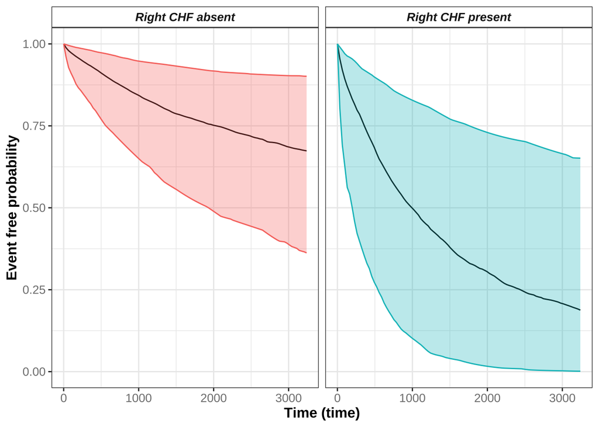

```r
panel_labels <- c('1' = "Right CHF absent", '2' = "Right CHF present")
pps <- plot(ps) +
  aes(colour = factor(id), fill = factor(id)) +
  theme(legend.position = "none") +
  facet_wrap(~ id, labeller = labeller(id = panel_labels)) +
           theme(axis.title.y = element_text(size=12, face="bold"),
               axis.title.x = element_text(size=12, face="bold"),
               title = element_text(size=12, face="bold"),
               plot.title = element_text(hjust = 0.5),
               axis.text.x = element_text(color = "grey50", size = 10),
               axis.text.y = element_text(color = "grey50",size = 10)) +
            theme(strip.text.x = element_text(size = 10, face = "bold.italic"),
                   strip.background = element_rect(fill="white")
        )
print(pps)
```

## Check PH assumption visually

### make predictions of both the hazard and log hazard

```r
ph <- suppressWarnings(posterior_survfit(mod_chf, newdata = nd, type = "haz"))
pl <- suppressWarnings(posterior_survfit(mod_chf, newdata = nd, type = "loghaz"))
```

#### create plots

```r
pph <- plot(ph) +
  coord_cartesian(ylim = c(0.0, 0.005)) +
  facet_wrap(~ id, labeller = labeller(id = panel_labels))
```

```
## ℹ Adding new coordinate system, which will replace the existing one.
```

```r
ppl <- plot(pl) +
  facet_wrap(~ id, labeller = labeller(id = panel_labels))
```

#### combine plots in grid and plot

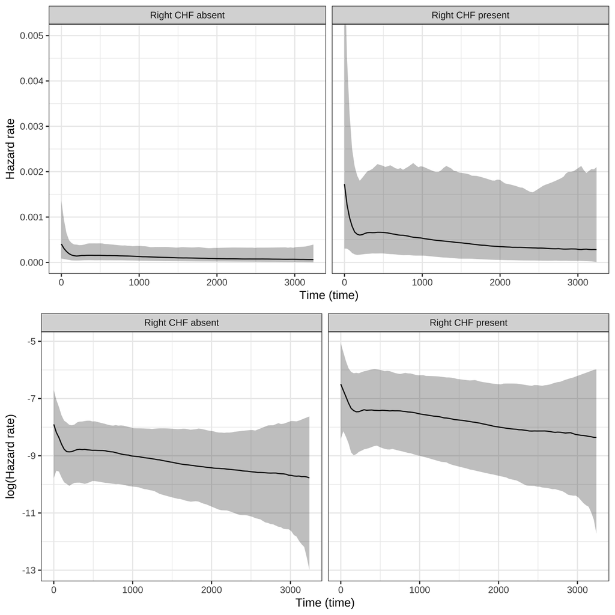

```r
plot_grid(pph, ppl, ncol = 1)
```

# XII. Bayesian multi-level survival analysis for effect of ATENOLOL with random intercept for centre and control set

## Set prior for beta variables

**Set an informative prior…**

student_t(df = 3, location = 1.866284, scale = 0.8443848)

```r
prior_beta_aten <- student_t(df = 3, location = c(1.866284, 0), scale = c(0.8443848, 2), autoscale = c(FALSE, TRUE))
```

Based on the DAG, use the following adjustment variables: RV syst dys, referral centre.

## Fit model

NB use status … rstanarm requires the dead animals to be classified as 1, whilst censored are 0.

```r
mod_aten <- stan_surv(formula = Surv(time, status) ~ atenolol
                      + s_tapse
                      + (1| centre),
  data = df,
  basehaz = "ms",
  prior_intercept = normal(location = 0, scale = 15, autoscale = FALSE),
  prior = prior_beta_aten,
  prior_covariance =  decov(regularization = 2, concentration = 1, shape = 1, scale = 1),
  iter    = 12000,
  warmup = 4000,
  chains = 4,
  cores = 4,
  adapt_delta = 0.999999,  # Often helpful for complex models
  control = list(max_treedepth = 20),
  init = 0.1,
  seed = 666)
```

[output not shown]

[output not shown]

[output not shown]

[output not shown]

[output not shown]

[output not shown]

[output not shown]

[output not shown]

[output not shown]

[output not shown]

## Summarise priors from model

```r
prior_summary(mod_aten)
```

```
## Priors for model 'mod_aten'
## ------
## Intercept
##  ~ normal(location = 0, scale = 15)
##
## Coefficients
##  ~ student_t(df = [3,3], location = [1.9,0.0], scale = [0.84,2.00])
##
## Auxiliary (M-spline-coefficients)
##  ~ dirichlet(concentration = [1,1,1,...])
##
## Covariance
##  ~ decov(reg. = 2, conc. = 1, shape = 1, scale = 1)
## ------
## See help('prior_summary.stanreg') for more details
```

## Model summary

```r
summary(mod_aten)
```

```
##
## Model Info:
##
##  function:        stan_surv
##  baseline hazard: M-splines on hazard scale
##  formula:         Surv(time, status) ~ atenolol + s_tapse + (1 | centre)
##  algorithm:       sampling
##  sample:          32000 (posterior sample size)
##  priors:          see help('prior_summary')
##  observations:    80
##  events:          27 (33.8%)
##  right censored:  53 (66.2%)
##  delayed entry:   no
##
## Estimates:
##                                         mean   sd   10%   50%   90%
## (Intercept)                            0.7    0.8 -0.3   0.8   1.7
## atenolol1                             -1.0    0.7 -1.8  -1.0  -0.1
## s_tapse                               -0.3    0.3 -0.6  -0.3   0.0
## m-splines-coef1                        0.1    0.0  0.0   0.1   0.2
## m-splines-coef2                        0.1    0.1  0.0   0.1   0.1
## m-splines-coef3                        0.4    0.1  0.2   0.4   0.6
## m-splines-coef4                        0.2    0.1  0.0   0.1   0.4
## m-splines-coef5                        0.1    0.1  0.0   0.1   0.3
## m-splines-coef6                        0.1    0.1  0.0   0.1   0.3
## b[(Intercept) centre:p]               -0.3    0.6 -0.9  -0.2   0.2
## b[(Intercept) centre:sath]             0.3    0.5 -0.1   0.2   0.9
## b[(Intercept) centre:willows]          0.0    0.5 -0.5   0.0   0.5
## Sigma[centre:(Intercept),(Intercept)]  0.6    1.5  0.0   0.2   1.5
##
## MCMC diagnostics
##                                       mcse Rhat n_eff
## (Intercept)                           0.0  1.0  10886
## atenolol1                             0.0  1.0  14973
## s_tapse                               0.0  1.0  23621
## m-splines-coef1                       0.0  1.0  39125
## m-splines-coef2                       0.0  1.0  21386
## m-splines-coef3                       0.0  1.0  29611
## m-splines-coef4                       0.0  1.0  24811
## m-splines-coef5                       0.0  1.0  34200
## m-splines-coef6                       0.0  1.0  33093
## b[(Intercept) centre:p]               0.0  1.0   9964
## b[(Intercept) centre:sath]            0.0  1.0   6648
## b[(Intercept) centre:willows]         0.0  1.0   7019
## Sigma[centre:(Intercept),(Intercept)] 0.0  1.0  10116
## log-posterior                         0.0  1.0   9031
##
## For each parameter, mcse is Monte Carlo standard error, n_eff is a crude measure of effective sample size, and Rhat is the potential scale reduction factor on split chains (at convergence Rhat=1).
```

## Model short summary

```r
print(mod_aten, digits = 3)
```

```
## stan_surv
##  baseline hazard: M-splines on hazard scale
##  formula:         Surv(time, status) ~ atenolol + s_tapse + (1 | centre)
##  observations:    80
##  events:          27 (33.8%)
##  right censored:  53 (66.2%)
##  delayed entry:   no
## ------
##                 Median MAD_SD exp(Median)
## (Intercept)      0.751  0.746     NA
## atenolol1       -1.005  0.686  0.366
## s_tapse         -0.264  0.253  0.768
## m-splines-coef1  0.092  0.046     NA
## m-splines-coef2  0.052  0.048     NA
## m-splines-coef3  0.431  0.151     NA
## m-splines-coef4  0.140  0.129     NA
## m-splines-coef5  0.088  0.086     NA
## m-splines-coef6  0.095  0.093     NA
##
## Error terms:
##  Groups Name        Std.Dev.
##  centre (Intercept) 0.7813
## Num. levels: centre 3
##
## ------
## * For help interpreting the printed output see ?print.stanreg
## * For info on the priors used see ?prior_summary.stanreg
```

## Check model performance

### 1. Check performance of posterior probability

NB equivalent of pp_check

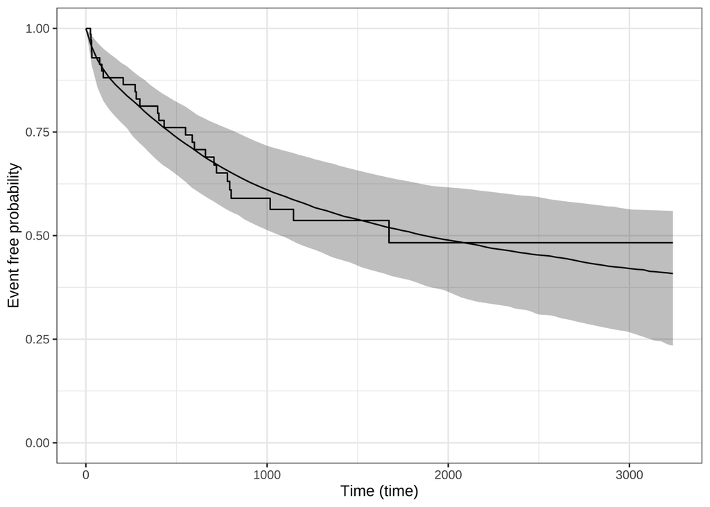

```r
ps_check(mod_aten) |>
  suppressWarnings()
```

### 2. Check performance of prior probability

```r
mod_aten_prior_only <- update(mod_aten, prior_PD = TRUE)
```

[output not shown]

[output not shown]

[output not shown]

[output not shown]

[output not shown]

[output not shown]

[output not shown]

[output not shown]

[output not shown]

[output not shown]

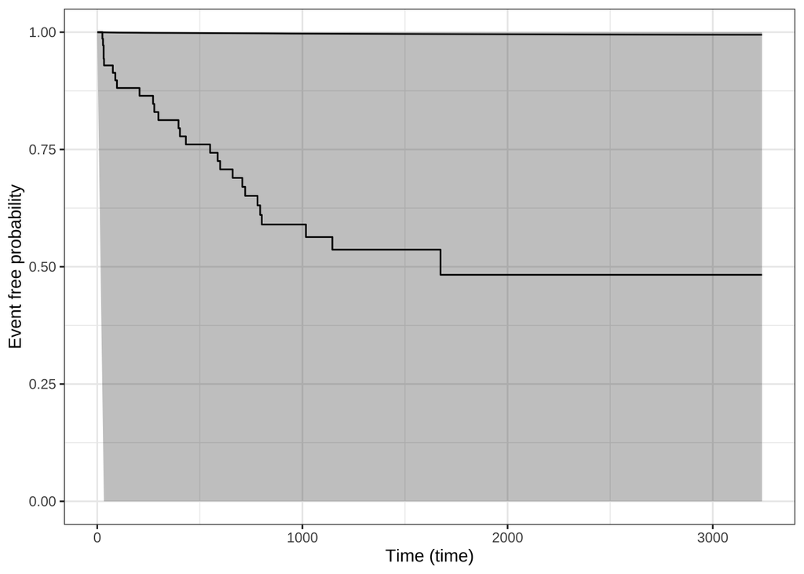

```r
ps_check(mod_aten_prior_only) |>
  suppressWarnings()
```

# XVI. Bayesian multi-level survival analysis for effect of CLINICAL SIGNS with random intercept for centre

## Set prior for beta variables

**Set an informative prior…**

student_t(df = 3, location = 1.150538, scale = 0.2454828)

```r
prior_clin_si <- student_t(df = 3, location = c(1.150538, 0, 0), scale = c(0.2454828 , 2, 2), autoscale = FALSE)
```

## Fit model

NB use status … rstanarm requires the dead animals to be classified as 1, whilst censored are 0.

```r
mod_clin_si <- stan_surv(formula = Surv(time, status) ~ clinical_signs
                         + chf
                         + arrhythmias
                         + (1| centre),
  data = df,
  basehaz = "ms",
  prior_intercept = normal(location = 0, scale = 12.5, autoscale = FALSE),
  prior = prior_clin_si,
  prior_covariance =  decov(regularization = 2, concentration = 1, shape = 1, scale = 1),
  iter    = 12000,
  warmup = 4000,
  chains = 4,
  cores = 4,
  adapt_delta = 0.99999,  # Often helpful for complex models
  seed = 666)
```

[output not shown]

[output not shown]

[output not shown]

[output not shown]

[output not shown]

[output not shown]

[output not shown]

[output not shown]

[output not shown]

[output not shown]

## Summarise priors from model

```r
prior_summary(mod_clin_si)
```

```
## Priors for model 'mod_clin_si'
## ------
## Intercept
##  ~ normal(location = 0, scale = 12)
##
## Coefficients
##  ~ student_t(df = [3,3,3], location = [1.2,0.0,0.0], scale = [0.25,2.00,2.00])
##
## Auxiliary (M-spline-coefficients)
##  ~ dirichlet(concentration = [1,1,1,...])
##
## Covariance
##  ~ decov(reg. = 2, conc. = 1, shape = 1, scale = 1)
## ------
## See help('prior_summary.stanreg') for more details
```

## Model summary

```r
summary(mod_clin_si)
```

```
##
## Model Info:
##
##  function:        stan_surv
##  baseline hazard: M-splines on hazard scale
##  formula:         Surv(time, status) ~ clinical_signs + chf + arrhythmias + (1 |
##     centre)
##  algorithm:       sampling
##  sample:          32000 (posterior sample size)
##  priors:          see help('prior_summary')
##  observations:    113
##  events:          37 (32.7%)
##  right censored:  76 (67.3%)
##  delayed entry:   no
##
## Estimates:
##                                         mean   sd   10%   50%   90%
## (Intercept)                           -0.7    0.6 -1.3  -0.6   0.0
## clinical_signs                         1.2    0.2  0.9   1.2   1.5
## chf1                                   1.2    0.4  0.6   1.2   1.7
## arrhythmias1                          -0.5    0.5 -1.2  -0.5   0.1
## m-splines-coef1                        0.1    0.0  0.0   0.1   0.1
## m-splines-coef2                        0.1    0.0  0.0   0.0   0.1
## m-splines-coef3                        0.4    0.2  0.2   0.4   0.6
## m-splines-coef4                        0.3    0.2  0.1   0.2   0.5
## m-splines-coef5                        0.1    0.1  0.0   0.1   0.3
## m-splines-coef6                        0.1    0.1  0.0   0.1   0.3
## b[(Intercept) centre:p]               -0.3    0.6 -0.9  -0.2   0.3
## b[(Intercept) centre:sath]             0.5    0.6  0.0   0.4   1.2
## b[(Intercept) centre:willows]         -0.2    0.6 -0.8  -0.1   0.4
## Sigma[centre:(Intercept),(Intercept)]  0.8    1.6  0.0   0.3   1.9
##
## MCMC diagnostics
##                                       mcse Rhat n_eff
## (Intercept)                           0.0  1.0  10140
## clinical_signs                        0.0  1.0  30611
## chf1                                  0.0  1.0  25080
## arrhythmias1                          0.0  1.0  28266
## m-splines-coef1                       0.0  1.0  37136
## m-splines-coef2                       0.0  1.0  26773
## m-splines-coef3                       0.0  1.0  26402
## m-splines-coef4                       0.0  1.0  23615
## m-splines-coef5                       0.0  1.0  38302
## m-splines-coef6                       0.0  1.0  37750
## b[(Intercept) centre:p]               0.0  1.0  10925
## b[(Intercept) centre:sath]            0.0  1.0   9627
## b[(Intercept) centre:willows]         0.0  1.0   9929
## Sigma[centre:(Intercept),(Intercept)] 0.0  1.0  12355
## log-posterior                         0.0  1.0   9019
##
## For each parameter, mcse is Monte Carlo standard error, n_eff is a crude measure of effective sample size, and Rhat is the potential scale reduction factor on split chains (at convergence Rhat=1).
```

## Model short summary

```r
print(mod_clin_si, digits = 3)
```

```
## stan_surv
##  baseline hazard: M-splines on hazard scale
##  formula:         Surv(time, status) ~ clinical_signs + chf + arrhythmias + (1 |
##     centre)
##  observations:    113
##  events:          37 (32.7%)
##  right censored:  76 (67.3%)
##  delayed entry:   no
## ------
##                 Median MAD_SD exp(Median)
## (Intercept)     -0.629  0.467     NA
## clinical_signs   1.159  0.223  3.186
## chf1             1.160  0.426  3.190
## arrhythmias1    -0.514  0.510  0.598
## m-splines-coef1  0.065  0.031     NA
## m-splines-coef2  0.048  0.039     NA
## m-splines-coef3  0.356  0.162     NA
## m-splines-coef4  0.242  0.180     NA
## m-splines-coef5  0.098  0.095     NA
## m-splines-coef6  0.092  0.091     NA
##
## Error terms:
##  Groups Name        Std.Dev.
##  centre (Intercept) 0.8983
## Num. levels: centre 3
##
## ------
## * For help interpreting the printed output see ?print.stanreg
## * For info on the priors used see ?prior_summary.stanreg
```

## Plot Baseline hazard of model

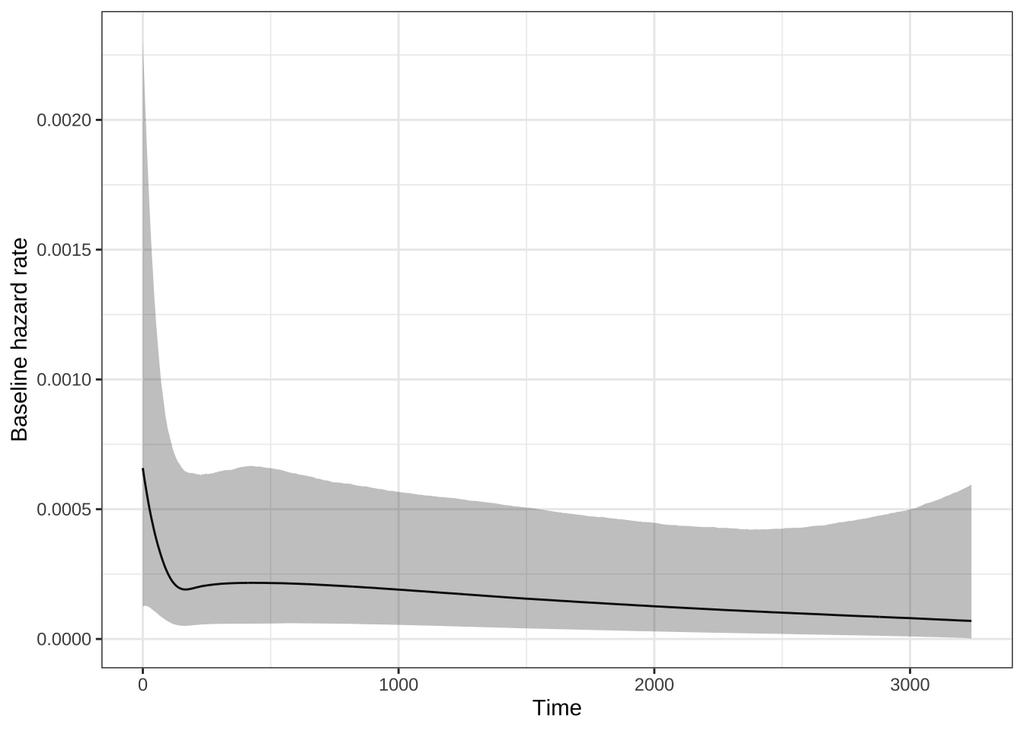

```r
plot(mod_clin_si)
```

## Plots of model convergences

## Get results

```r
posterior_mod_clin_si <- as.array(mod_clin_si)
```

### a. Check trace plots for model

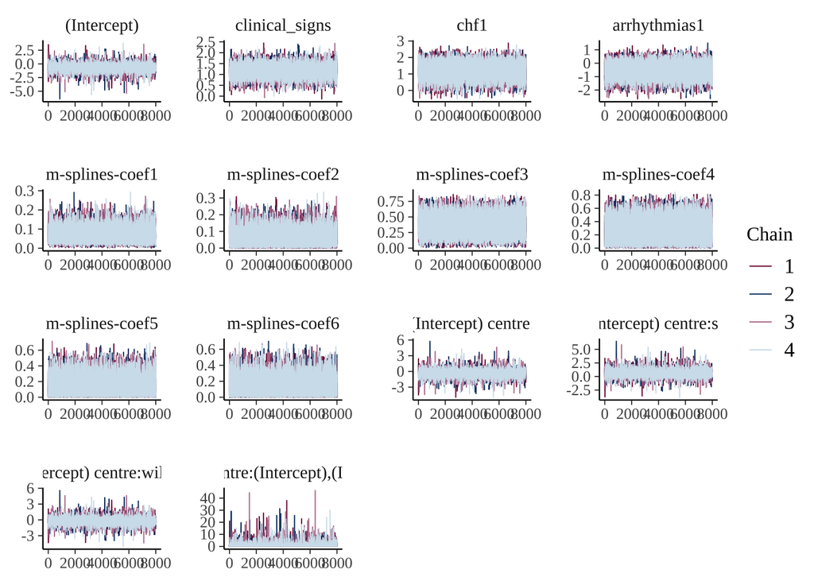

```r
color_scheme_set("mix-blue-pink")
mcmc_trace(posterior_mod_clin_si)
```

### b. Trace rank plot

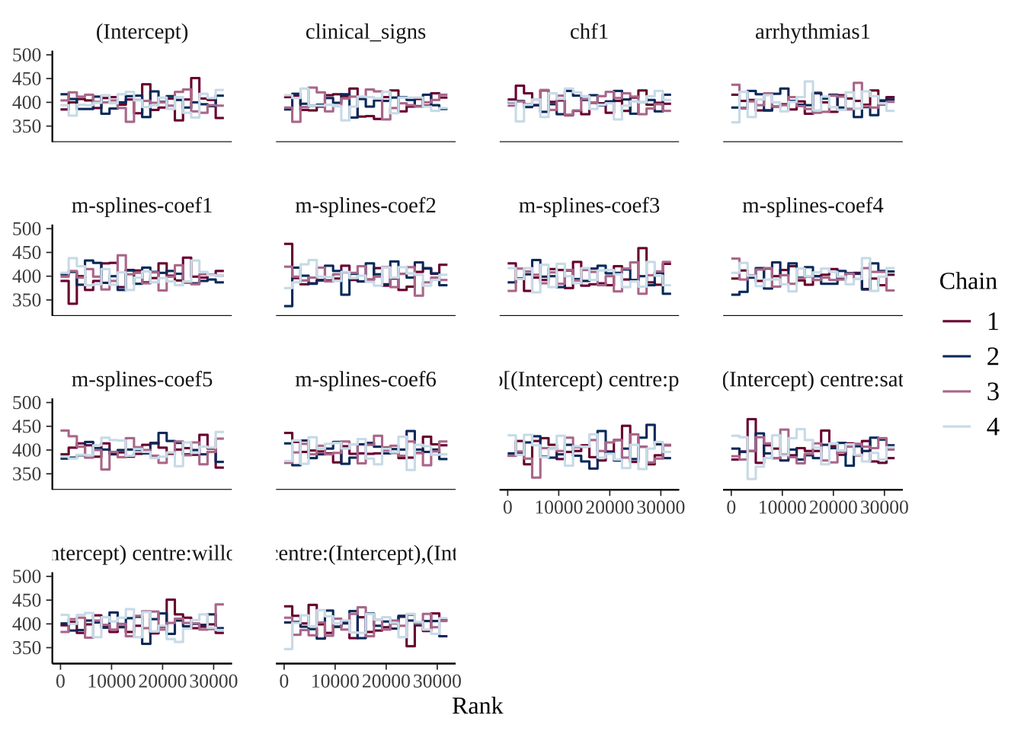

```r
color_scheme_set("mix-blue-pink")
mcmc_rank_overlay(posterior_mod_clin_si) +
  ylim(325, 500)
```

### c. get dens overlay plot for chains

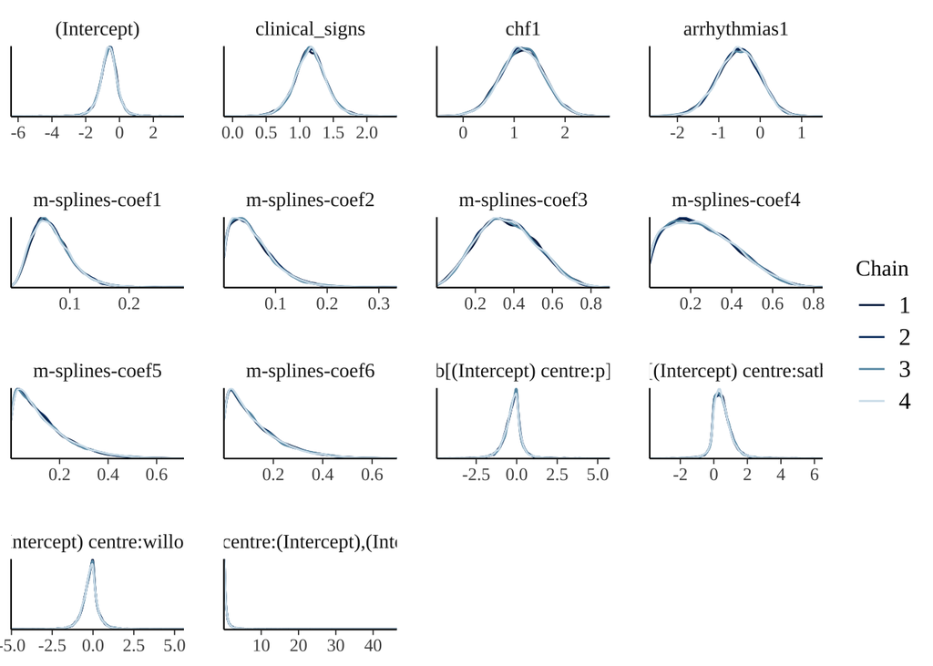

```r
color_scheme_set("blue")
mcmc_dens_overlay(posterior_mod_clin_si)
```

## Summaries of coefficients

### a. HPDI for the different beta parameters

```r
draws <- as.matrix(mod_clin_si)
median(draws[,2]) # draws for clinical_signs
```

```
## [1] 1.158819
```

```r
HPDI(draws[,2], 0.97) # draws for clinical_signs
```

```
##    |0.97    0.97|
## 0.598997 1.718489
```

```r
HPDI(draws[,2], 0.89) # draws for clinical_signs
```

```
##     |0.89     0.89|
## 0.7780689 1.5459350
```

### b. Hypothesis tests on beta parameters

probability that effect is positive

```r
mean(draws[,2] > 0) # draws for clinical_signs
```

```
## [1] 0.9999375
```

### c. Plot posterior distribution for beta coefficient of clinical_signs

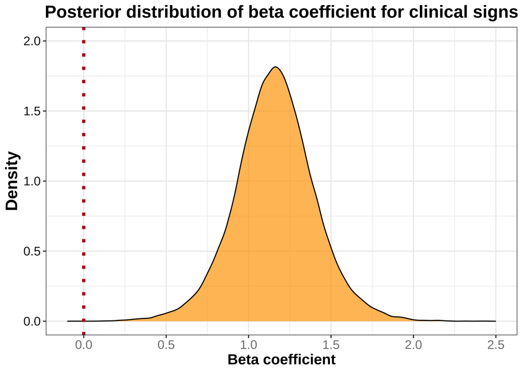

```r
s_cs <- draws[,2] # 2nd column is draws for clinical_signs

ggplot(data.frame(s_cs), aes(x = s_cs)) +
  geom_density(fill = "orange", alpha = 0.7) +
  labs(title = "Posterior distribution of beta coefficient for clinical signs",
       x = "Beta coefficient",
       y = "Density") +
  theme_bw() +
           theme(axis.title.y = element_text(size=16, face="bold"),
               axis.title.x = element_text(size=14, face="bold"),
               title = element_text(size=14, face="bold"),
               plot.title = element_text(hjust = 0.5),
               axis.text.x = element_text(color = "grey50", size = 12),
               axis.text.y = element_text(color = "grey8",size = 12)) +
  geom_vline(xintercept = 0, linetype="dotted",
                color = "firebrick", linewidth = 1.5) +
  xlim(-0.1, 2.5) +
  ylim(0, 2.0)
```

## Get HDI for coefficients

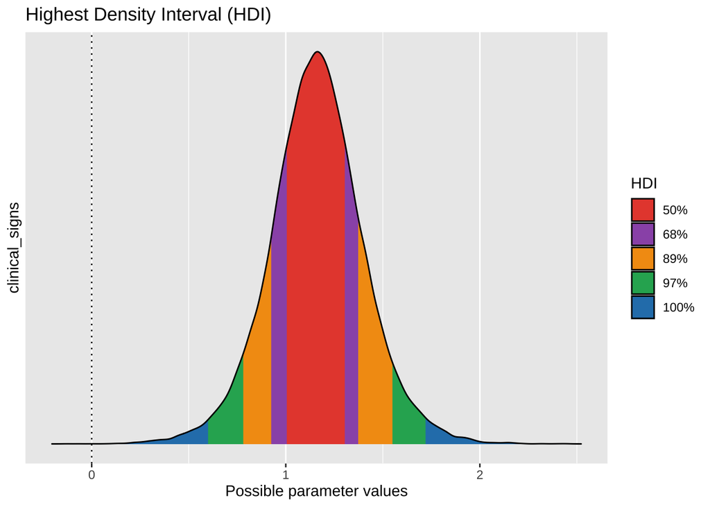

```r
hdi <- bayestestR::hdi(mod_clin_si, ci = c(0.50, 0.68, 0.89, 0.97), parameters = "clinical_signs")
plot(hdi)
```

## Get density plots for posterior distributons of beta parameters

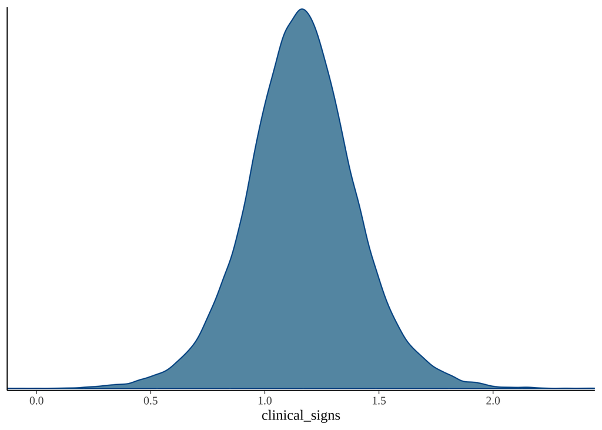

```r
mcmc_dens(posterior_mod_clin_si,
  pars = c("clinical_signs"))
```

## Get area plot for posterior distributons of beta parameters

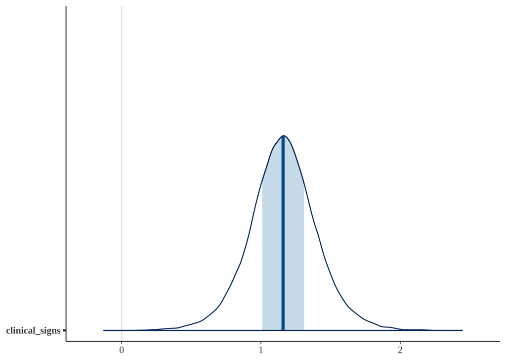

```r
mcmc_areas(posterior_mod_clin_si,
  pars = "clinical_signs")
```

## Calculate hazard ratios for clinical_signs

### a. get posterior draws

```r
clin_si_hr <- exp(draws[,2]) # draws for clinical_signs
```

### b. Summarise hazard ratios for clinical_signs

```r
median(clin_si_hr)
```

```
## [1] 3.186167
```

```r
hpdi_clin_si <- HPDI(clin_si_hr, prob = c(0.89, 0.97))
hpdi_clin_si
```

```
##    |0.97    |0.89    0.89|    0.97|
## 1.613145 2.013663 4.444176 5.257932
```

### c. Plot posterior distribution for hazard ratio of clin_si_hi

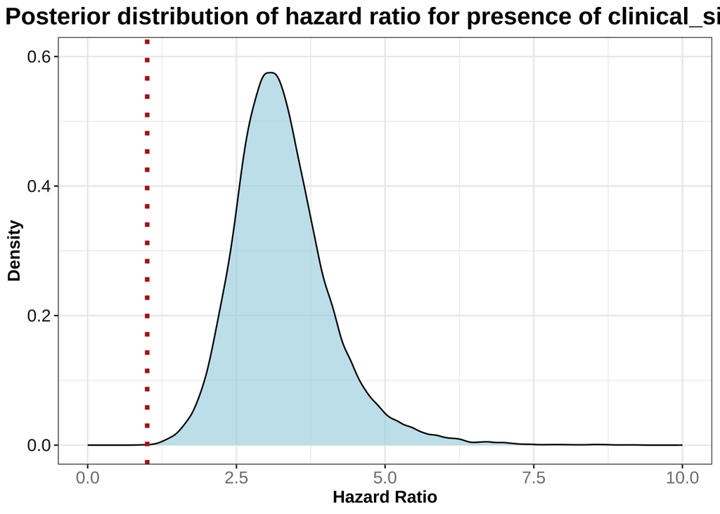

```r
ggplot(data.frame(clin_si_hr), aes(x = clin_si_hr)) +
  geom_density(fill = "lightblue", alpha = 0.7) +
  labs(title = "Posterior distribution of hazard ratio for presence of clinical_signs",
       x = "Hazard Ratio",
       y = "Density") +
  theme_bw() +
           theme(axis.title.y = element_text(size=12, face="bold"),
               axis.title.x = element_text(size=12, face="bold"),
               title = element_text(size=14, face="bold"),
               plot.title = element_text(hjust = 0.5),
               axis.text.x = element_text(color = "grey50", size = 12),
               axis.text.y = element_text(color = "grey8",size = 12)) +
  geom_vline(xintercept = 1, linetype="dotted",
                color = "firebrick", linewidth = 1.5) +
  xlim(0, 10) +
  ylim(0, 0.6)
```

## Check model performance

### 1. Check performance of posterior probability

NB equivalent of pp_check

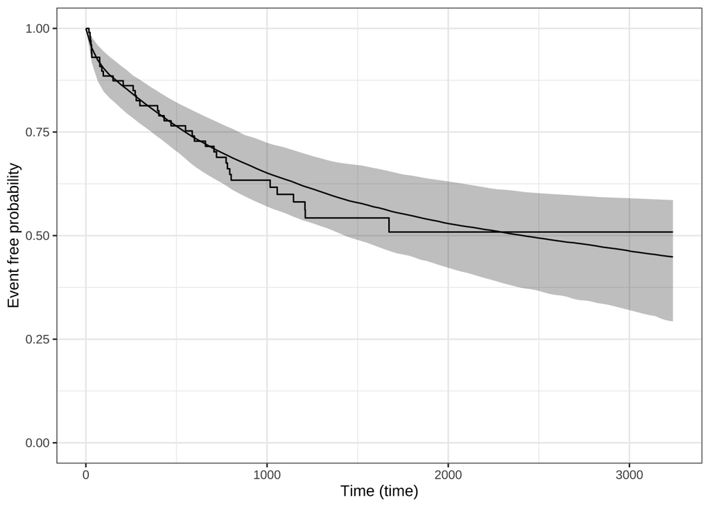

```r
ps_check(mod_clin_si) |>
  suppressWarnings()
```